# Loan default prediction

## Loading the dataset

```r
loan<- read.csv("lc_loan2.csv")
```

## What problem are you trying to solve?

People require financial support or funding for various reasons. The main source from which people get funding is banks/lenders in the form of loans. When people successfully repay their loans, the transaction is beneficial to both the bank/lender and the borrower. However, on some occasions, borrowers fail to repay the loan and the banks/lenders suffers a huge loss. Hence, banks/lenders have to be selective while sanctioning loans. This project aims to predict the likelihood of a borrower defaulting on the loan. In addition, classify borrowers into various categories of risks. This will help lenders further understand the risk involved in a loan and decide whether to approve it or not.

## What data have you chosen ?(chosen Dataset, source of dataset, description of dataset, basic commands to describe dataset)

- Chosen dataset - Lending Club loan dataset
- Source of dataset - https://data.world/lpetrocelli/lendingclub-loan-data-2017-q-1

## Description:-

### This is LendingClub’s complete loan data for all loans issued from 2007 to 2018 in US.

### Dimension of the dataset

```r
dim(loan)
```

```
## [1] 887378     74
```

### Column names

```r
colnames(loan)
```

```
##  [1] "id"                          "member_id"
##  [3] "loan_amnt"                   "funded_amnt"
##  [5] "funded_amnt_inv"             "term"
##  [7] "int_rate"                    "installment"
##  [9] "grade"                       "sub_grade"
## [11] "emp_title"                   "emp_length"
## [13] "home_ownership"              "annual_inc"
## [15] "verification_status"         "issue_d"
## [17] "loan_status"                 "pymnt_plan"
## [19] "url"                         "desc"
## [21] "purpose"                     "title"
## [23] "zip_code"                    "addr_state"
## [25] "dti"                         "delinq_2yrs"
## [27] "earliest_cr_line"            "inq_last_6mths"
## [29] "mths_since_last_delinq"      "mths_since_last_record"
```

[output cut: 22 more lines]

### head of the dataset

```r
head(loan,5)
```

```
##         id member_id loan_amnt funded_amnt funded_amnt_inv       term int_rate
## 1 76393891        NA     20400       20400           20400  36 months    10.75
## 2 23845979        NA     10000       10000           10000  36 months     8.39
## 3 53584672        NA     25000       25000           25000  60 months    21.99
## 4  3638038        NA     10850       10850           10850  36 months    11.14
## 5 78258486        NA     12000       12000           12000  60 months    10.75
##   installment grade sub_grade                   emp_title emp_length
## 1      665.46     B        B4                Fire Fighter    9 years
## 2      315.17     A        A5          Physical Therapist    2 years
## 3      690.34     F        F1           Assistant Manager  10+ years
## 4      355.94     B        B2 Garden City School District    2 years
## 5      259.42     B        B4       FireFighter Paramedic  10+ years
##   home_ownership annual_inc verification_status  issue_d loan_status pymnt_plan
## 1       MORTGAGE      75000     Source Verified Apr-2016  Fully Paid          n
## 2       MORTGAGE      66310        Not Verified Aug-2014  Fully Paid          n
```

[output cut: 81 more lines]

### Structure of the dataset

```r
str(loan)
```

```
## 'data.frame':    887378 obs. of  74 variables:
##  $ id                         : chr  "76393891" "23845979" "53584672" "3638038" ...
##  $ member_id                  : logi  NA NA NA NA NA NA ...
##  $ loan_amnt                  : int  20400 10000 25000 10850 12000 10800 19500 28000 15000 4200 ...
##  $ funded_amnt                : int  20400 10000 25000 10850 12000 10800 19500 28000 15000 4200 ...
##  $ funded_amnt_inv            : num  20400 10000 25000 10850 12000 ...
##  $ term                       : chr  " 36 months" " 36 months" " 60 months" " 36 months" ...
##  $ int_rate                   : num  10.75 8.39 21.99 11.14 10.75 ...
##  $ installment                : num  665 315 690 356 259 ...
##  $ grade                      : chr  "B" "A" "F" "B" ...
##  $ sub_grade                  : chr  "B4" "A5" "F1" "B2" ...
##  $ emp_title                  : chr  "Fire Fighter" "Physical Therapist" "Assistant Manager" "Garden City School District" ...
##  $ emp_length                 : chr  "9 years" "2 years" "10+ years" "2 years" ...
##  $ home_ownership             : chr  "MORTGAGE" "MORTGAGE" "MORTGAGE" "RENT" ...
##  $ annual_inc                 : num  75000 66310 57000 41000 54000 ...
```

[output cut: 60 more lines]

### Summary

```r
summary(loan)
```

```
##       id            member_id        loan_amnt      funded_amnt
##  Length:887378      Mode:logical   Min.   :  500   Min.   :  500
##  Class :character   NA's:887378    1st Qu.: 8000   1st Qu.: 8000
##  Mode  :character                  Median :12400   Median :12375
##                                    Mean   :14668   Mean   :14659
##                                    3rd Qu.:20000   3rd Qu.:20000
##                                    Max.   :40000   Max.   :40000
##                                    NA's   :33      NA's   :33
##  funded_amnt_inv     term              int_rate      installment
##  Min.   :    0   Length:887378      Min.   : 5.31   Min.   :   4.93
##  1st Qu.: 8000   Class :character   1st Qu.:10.08   1st Qu.: 253.18
##  Median :12275   Mode  :character   Median :13.18   Median : 380.24
##  Mean   :14628                      Mean   :13.68   Mean   : 443.99
##  3rd Qu.:20000                      3rd Qu.:16.55   3rd Qu.: 587.34
##  Max.   :40000                      Max.   :30.99   Max.   :1719.83
##  NA's   :33                         NA's   :33      NA's   :33
##     grade            sub_grade          emp_title          emp_length
##  Length:887378      Length:887378      Length:887378      Length:887378
##  Class :character   Class :character   Class :character   Class :character
##  Mode  :character   Mode  :character   Mode  :character   Mode  :character
##
##
##
##
##  home_ownership       annual_inc      verification_status   issue_d
##  Length:887378      Min.   :      0   Length:887378       Length:887378
##  Class :character   1st Qu.:  45000   Class :character    Class :character
##  Mode  :character   Median :  65000   Mode  :character    Mode  :character
##                     Mean   :  75428
##                     3rd Qu.:  90000
##                     Max.   :9573072
##                     NA's   :37
##  loan_status         pymnt_plan            url                desc
##  Length:887378      Length:887378      Length:887378      Length:887378
##  Class :character   Class :character   Class :character   Class :character
##  Mode  :character   Mode  :character   Mode  :character   Mode  :character
##
##
##
##
```

[output cut: 97 more lines]

```
##  Min.   :     0   Min.   :  0.0    Min.   :      0   Min.   : 0.0
##  1st Qu.:  2145   1st Qu.: 45.0    1st Qu.:  13900   1st Qu.: 0.0
##  Median :  4129   Median : 60.0    Median :  23700   Median : 1.0
##  Mean   :  5454   Mean   : 58.8    Mean   :  32168   Mean   : 1.1
##  3rd Qu.:  7082   3rd Qu.: 73.0    3rd Qu.:  39900   3rd Qu.: 2.0
##  Max.   :571793   Max.   :204.0    Max.   :2013133   Max.   :28.0
##  NA's   :510102   NA's   :510142   NA's   :44070     NA's   :510102
##   total_cu_tl      inq_last_12m    fico_range_high fico_range_low
##  Min.   : 0.0     Min.   : 0.0     Min.   :614.0   Min.   :610.0
##  1st Qu.: 0.0     1st Qu.: 1.0     1st Qu.:674.0   1st Qu.:670.0
##  Median : 0.0     Median : 2.0     Median :689.0   Median :685.0
##  Mean   : 1.6     Mean   : 2.4     Mean   :698.9   Mean   :694.9
##  3rd Qu.: 2.0     3rd Qu.: 3.0     3rd Qu.:714.0   3rd Qu.:710.0
##  Max.   :79.0     Max.   :67.0     Max.   :850.0   Max.   :845.0
##  NA's   :510103   NA's   :510103   NA's   :33      NA's   :33
```

## Objectives:-

### 1. Performing data manipulation, data cleaning

### 2. Building logistic regression model, decision tree, random forest model and SVM to predict the likelihood of a borrower defaulting on the loan, thus helping decide whether loan should be approved or not.

### 3. Comparing the performance of the models.

### 4. Building a classification model to classify loans into 1 of 7 categories from A to G, to indicate the risk involved.

### 5. Comparing the performance of the multi-class models.

## Is there any work previously reported on the problem and the data? If so, discuss it here.

### Some work has been carried out on the dataset to perform loan approval using models employing various machine learning algorithms like logistic regression, SVM and Gradient Boosting machine.

### Loading libraries

```r
library(nnet)
library(tidyverse)
library(caret)
library(car)
library(broom)
library(caTools)
library(dplyr)
library(party)
library(magrittr)
library(rpart)
library(rpart.plot)
library(caret)
library(e1071)
library(klaR)
library(rpart.plot)
library(randomForest)
library(kernlab)
library(xgboost)
library(lubridate)
library(ggpubr)
library(pROC)
library(gbm)
library(knitr)
```

```r
table(loan$loan_status)
```

```
##
##
##                                                  33
##                                         Charged Off
##                                              268559
##                                             Default
##                                                  40
## Does not meet the credit policy. Status:Charged Off
##                                                 761
##  Does not meet the credit policy. Status:Fully Paid
##                                                1988
##                                          Fully Paid
##                                              581745
##                                     In Grace Period
##                                                8436
##                                   Late (16-30 days)
##                                                4349
##                                  Late (31-120 days)
##                                               21467
```

#### Checking number of missing elements in columns

```r
colSums(is.na(loan))
```

```
##                          id                   member_id
##                           0                      887378
##                   loan_amnt                 funded_amnt
##                          33                          33
##             funded_amnt_inv                        term
##                          33                           0
##                    int_rate                 installment
##                          33                          33
##                       grade                   sub_grade
##                           0                           0
##                   emp_title                  emp_length
##                           0                           0
##              home_ownership                  annual_inc
##                           0                          37
##         verification_status                     issue_d
##                           0                           0
##                 loan_status                  pymnt_plan
##                           0                           0
##                         url                        desc
##                           0                           0
##                     purpose                       title
##                           0                           0
##                    zip_code                  addr_state
##                           0                           0
##                         dti                 delinq_2yrs
##                         299                          62
##            earliest_cr_line              inq_last_6mths
##                           0                          63
##      mths_since_last_delinq      mths_since_last_record
##                      443825                      733132
##                    open_acc                     pub_rec
##                          62                          62
##                   revol_bal                  revol_util
##                          33                         661
##                   total_acc         initial_list_status
##                          62                           0
##                   out_prncp               out_prncp_inv
##                          33                          33
##                 total_pymnt             total_pymnt_inv
##                          33                          33
```

[output cut: 19 more lines]

```
##                       44070                      510103
##                 open_il_12m          mths_since_rcnt_il
##                      510102                      520710
##                total_bal_il                     il_util
##                      510102                      561111
##                 open_rv_12m                 open_rv_24m
##                      510102                      510102
##                  max_bal_bc                    all_util
##                      510102                      510142
##            total_rev_hi_lim                      inq_fi
##                       44070                      510102
##                 total_cu_tl                inq_last_12m
##                      510103                      510103
##             fico_range_high              fico_range_low
##                          33                          33
```

#### Removing columns with 1 or less distinct elements

```r
ndisColums <- c()
for( i in 1:ncol(loan))
  if(n_distinct(loan[,i]) <= 1 ){
    ndisColums = c(ndisColums, colnames(loan)[i])
  }
ndisColums
```

```
## [1] "member_id"
```

```r
loan[ ,ndisColums]<- NULL
```

#### Removing columns with more than 25% missing elements

```r
remColumns <- c()
for( i in colnames(loan))
  if(colSums(is.na(loan[c(i)])) > 200000 ){
    remColumns = c(remColumns, i)
  }
remColumns
```

```
##  [1] "mths_since_last_delinq"      "mths_since_last_record"
##  [3] "mths_since_last_major_derog" "annual_inc_joint"
##  [5] "dti_joint"                   "open_acc_6m"
##  [7] "open_il_12m"                 "mths_since_rcnt_il"
##  [9] "total_bal_il"                "il_util"
## [11] "open_rv_12m"                 "open_rv_24m"
## [13] "max_bal_bc"                  "all_util"
## [15] "inq_fi"                      "total_cu_tl"
## [17] "inq_last_12m"
```

```r
loan[ ,remColumns]<- NULL
```

```r
sort(colnames(loan))
```

```
##  [1] "acc_now_delinq"             "addr_state"
##  [3] "annual_inc"                 "application_type"
##  [5] "collection_recovery_fee"    "collections_12_mths_ex_med"
##  [7] "delinq_2yrs"                "desc"
##  [9] "dti"                        "earliest_cr_line"
## [11] "emp_length"                 "emp_title"
## [13] "fico_range_high"            "fico_range_low"
## [15] "funded_amnt"                "funded_amnt_inv"
## [17] "grade"                      "home_ownership"
## [19] "id"                         "initial_list_status"
## [21] "inq_last_6mths"             "installment"
## [23] "int_rate"                   "issue_d"
## [25] "last_credit_pull_d"         "last_pymnt_amnt"
## [27] "last_pymnt_d"               "loan_amnt"
## [29] "loan_status"                "next_pymnt_d"
## [31] "open_acc"                   "out_prncp"
## [33] "out_prncp_inv"              "policy_code"
## [35] "pub_rec"                    "purpose"
## [37] "pymnt_plan"                 "recoveries"
## [39] "revol_bal"                  "revol_util"
## [41] "sub_grade"                  "term"
## [43] "title"                      "tot_coll_amt"
## [45] "tot_cur_bal"                "total_acc"
## [47] "total_pymnt"                "total_pymnt_inv"
## [49] "total_rec_int"              "total_rec_late_fee"
## [51] "total_rec_prncp"            "total_rev_hi_lim"
## [53] "url"                        "verification_status"
## [55] "verification_status_joint"  "zip_code"
```

```r
loan%>%filter(funded_amnt == loan_amnt)%>%summarize(n())
```

```
##      n()
## 1 885969
```

```r
loan[, "funded_amnt"] <- NULL
```

```r
remColumns <- c('funded_amnt_inv','desc' , 'collection_recovery_fee', 'collections_12_mths_ex_med',
                'url','policy_code', 'tot_coll_amt', 'emp_title',
                'total_pymnt_inv',
                'total_rev_hi_lim', 'title')
loan[, remColumns]<- NULL
```

```r
loan <- loan%>%filter(loan_status == "Fully Paid"| loan_status == "Charged Off")
loan <- loan%>%filter( (loan_status == 'Charged Off')| (loan_amnt <= total_rec_prncp & loan_status == 'Fully Paid'))
loan <- loan%>%filter(dti >=0 && dti <= 100)
```

```r
loan$addr_state <- as.factor(loan$addr_state)
loan$grade <- as.factor(loan$grade)
loan$purpose <- as.factor(loan$purpose)
loan$application_type <- as.factor(loan$application_type)
loan$home_ownership <- as.factor(loan$home_ownership)

loan <- loan%>%mutate(term = gsub(' ','', term))%>%mutate(term = gsub('months','', term))
loan$term <- as.numeric(loan$term)
loan$id <- NULL
loan$zip_code <- NULL
loan$verification_status_joint <- NULL
```

```r
loan<-loan%>%separate(issue_d, c('issue_mon', 'issue_yr'), "-")
loan$issue_yr<- as.factor(loan$issue_yr)
loan$issue_mon <- as.factor(loan$issue_mon)
loan$verification_status <- as.factor(loan$verification_status)
loan$sub_grade <- as.factor(loan$sub_grade)

loan$loan_status <- as.factor(loan$loan_status)
loan$emp_length <- as.factor(loan$emp_length)

loan$pymnt_plan <- NULL
loan$initial_list_status <- NULL
loan$next_pymnt_d <- NULL

loan$outcome <- as.factor(ifelse(loan$loan_status == "Fully Paid", 0 , 1))
loan$loan_status <- factor(ifelse(loan$loan_status == "Fully Paid", "Fully.Paid" , "Charged.Off"), levels = c("Fully.Paid" , "Charged.Off"))
loan <- na.omit(loan)
```

## EDA

```r
state_freq<-loan%>%group_by(addr_state)%>%
  summarize("count" = n())%>%
  arrange(desc(count))%>%
  mutate("prct" = (count/sum(count))*100)
```

```r
state_freq
```

```
## # A tibble: 51 x 3
##    addr_state  count  prct
##    <fct>       <int> <dbl>
##  1 CA         116470 14.4
##  2 TX          66706  8.26
##  3 NY          66082  8.18
##  4 FL          57807  7.16
##  5 IL          30662  3.80
##  6 NJ          29040  3.60
##  7 PA          27333  3.38
##  8 OH          26461  3.28
##  9 GA          25762  3.19
## 10 NC          23078  2.86
## # ... with 41 more rows
```

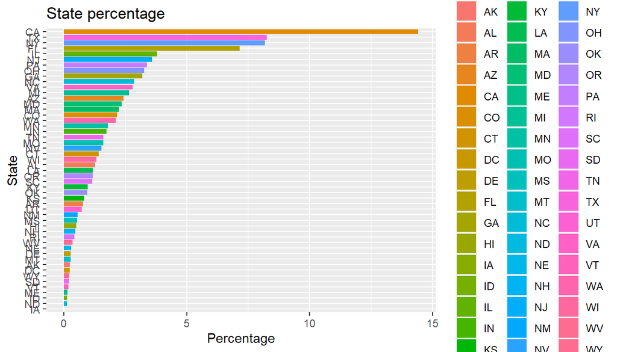

```r
ggplot(state_freq, aes(x=reorder(addr_state,prct), y = prct, fill = addr_state))+
  geom_bar(stat="identity")+coord_flip()+
  labs(x = "State", y= "Percentage", title = "State percentage")
```

### Inferences

#### California has the highest number of loans, hence most borrowers are from California.

### Employment length

```r
emp_per<-loan%>%group_by(emp_length)%>%
  summarize("count" = n())%>%
  arrange(desc(count))%>%
  mutate("prct" = (count/sum(count))*100)
```

```r
emp_per
```

```
## # A tibble: 12 x 3
##    emp_length   count  prct
##    <fct>        <int> <dbl>
##  1 "10+ years" 266973 33.1
##  2 "2 years"    72679  9.00
##  3 "3 years"    64461  7.98
##  4 "< 1 year"   64147  7.94
##  5 "1 year"     52791  6.54
##  6 ""           50668  6.27
##  7 "5 years"    49256  6.10
##  8 "4 years"    47372  5.86
##  9 "6 years"    36747  4.55
## 10 "8 years"    36639  4.54
## 11 "7 years"    35359  4.38
## 12 "9 years"    30681  3.80
```

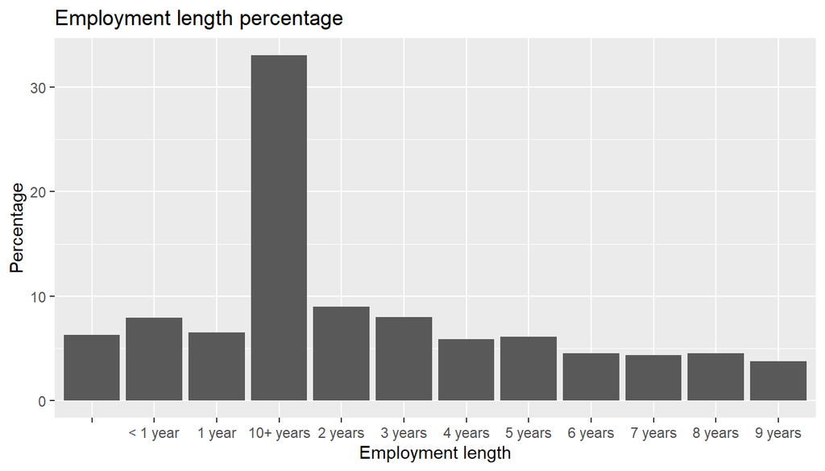

```r
ggplot(emp_per, aes(x=emp_length, y = prct))+
  geom_bar(stat='identity')+
  labs(x = "Employment length", y= "Percentage", title = "Employment length percentage")
```

### Year

```r
yrs_per<-loan%>%group_by(issue_yr)%>%
  summarize("count" = n())%>%
  arrange(desc(count))%>%
  mutate("prct" = (count/sum(count))*100)
```

```r
yrs_per
```

```
## # A tibble: 7 x 3
##   issue_yr  count  prct
##   <fct>     <int> <dbl>
## 1 2015     237407 29.4
## 2 2016     189297 23.4
## 3 2014     139075 17.2
## 4 2017     109507 13.6
## 5 2013      82357 10.2
## 6 2018      34373  4.26
## 7 2012      15757  1.95
```

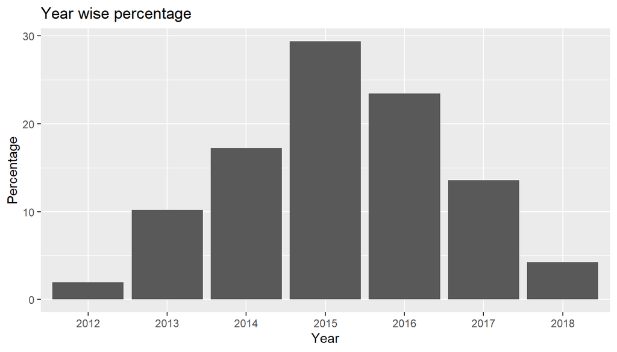

```r
ggplot(yrs_per, aes(x=issue_yr, y = prct))+
  geom_bar(stat='identity')+
  labs(x = "Year", y= "Percentage", title = "Year wise percentage")
```

### Inference

#### The number of loans granted is highest in the year 2015.

### Interest Rate and loan status

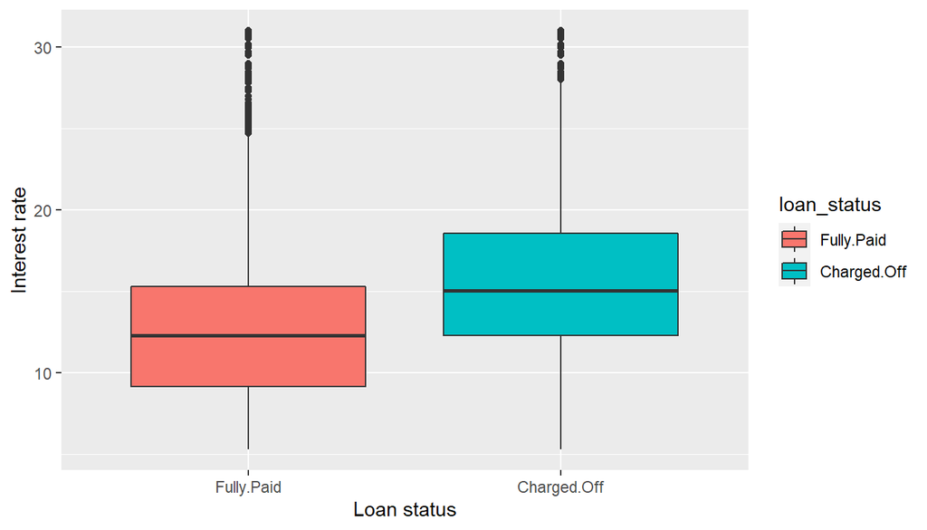

```r
ggplot(loan, aes(x = loan_status, y=int_rate, fill=loan_status))+geom_boxplot() +
  labs(x = "Loan status", y= "Interest rate")
```

### Inference

#### Charged-off loans have a higher interest rate than fully paid loans, because risky loans are given a higher interest.

### Grade and Loan status

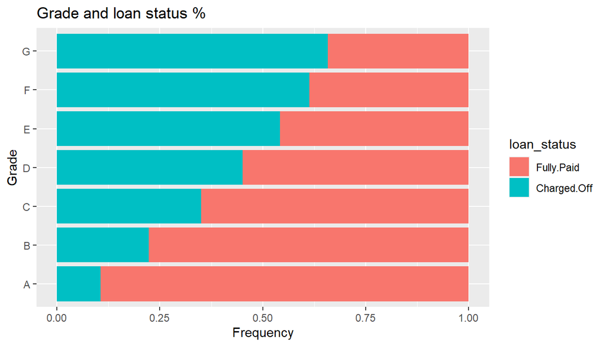

```r
ggplot(loan, aes(x=(grade), fill = loan_status))+
  geom_bar(stat = 'count', position = 'fill')+ coord_flip() +
  labs(x = "Grade", y= "Frequency", title = "Grade and loan status %")
```

### Inference

#### The percentage of defaulted loans or charged off loans are decreasing as grade improves. Thus, loans with grade ‘A’ are the least risky and loans with grade ‘G’ are the most risky.

### Grade and Interest Rate

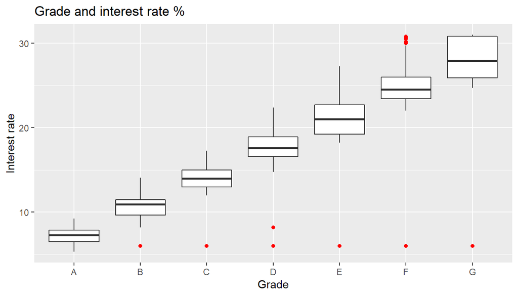

```r
ggplot(loan, aes(x=grade, y= int_rate))+
  geom_boxplot(outlier.colour = 'red')+
  labs(x = "Grade", y= "Interest rate", title = "Grade and interest rate %")
```

### Inference

#### As the grade decreases, the interest rate increases. Hence low grade loans are charged a high interest, since the risk is high.

### FICO score - Grade

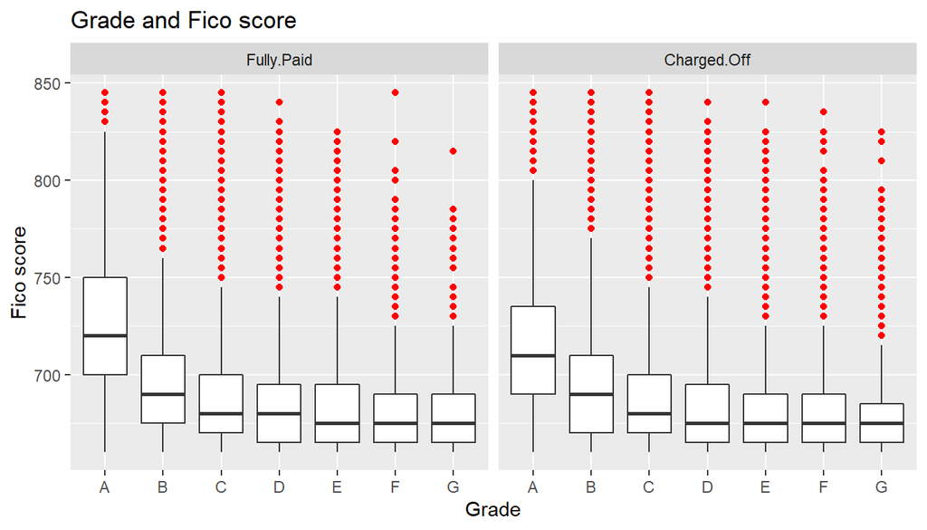

```r
ggplot(loan, aes(x=grade, y= fico_range_low))+
  geom_boxplot(outlier.colour = 'red')+ facet_wrap(.~loan_status)+
  labs(x = "Grade", y= "Fico score", title = "Grade and Fico score")
```

### FICO score - percentage of bad loans

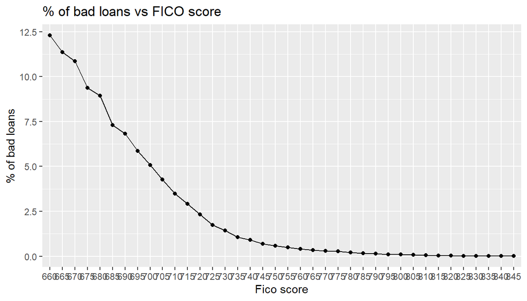

```r
fico_loss <- loan%>%filter(loan_status == 'Charged.Off')%>%group_by(fico_range_low)%>%summarize('count' = n())%>%
  mutate('prcnt' = (count/sum(count))*100)

ggplot(fico_loss , aes(x= as.factor(fico_range_low), y = prcnt, group = 1)) +  geom_line()+ geom_point()+
  labs(x = 'Fico score', y = '% of bad loans', title = '% of bad loans vs FICO score')
```

### Inference

#### As the FICO score increases the percentage of bad loans(charged-off loans) is decreasing, which indicates that risk is low if the FICO score is high and that the borrower is less likely to default or not pay back the loan if the FICO score is high.

### Delinquency in past 2yrs and Charge-off Rate

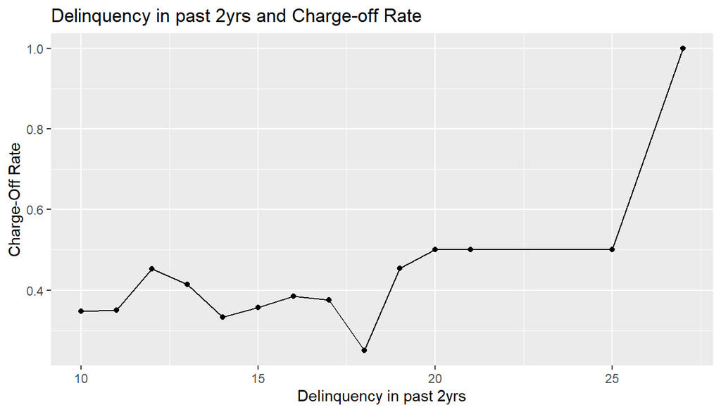

```r
delinq_chrff <- loan%>%filter(delinq_2yrs >= 10, loan_status == "Charged.Off")%>%group_by(delinq_2yrs)%>%summarise("chroff_cnt" = n())

delinq_main <- loan%>%filter(delinq_2yrs >= 10)%>%group_by(delinq_2yrs)%>%summarise("Total" = n())

delinq_main <- left_join(delinq_chrff, delinq_main, by = "delinq_2yrs")

delinq_main$chroff_rate <- delinq_main$chroff_cnt/delinq_main$Total

ggplot(delinq_main, aes(x=delinq_2yrs, y =chroff_rate, group =1))+geom_point()+geom_line()+
  labs(x="Delinquency in past 2yrs", y="Charge-Off Rate", title = "Delinquency in past 2yrs and Charge-off Rate")
```

### Number of inquiries in past 6 months and grade

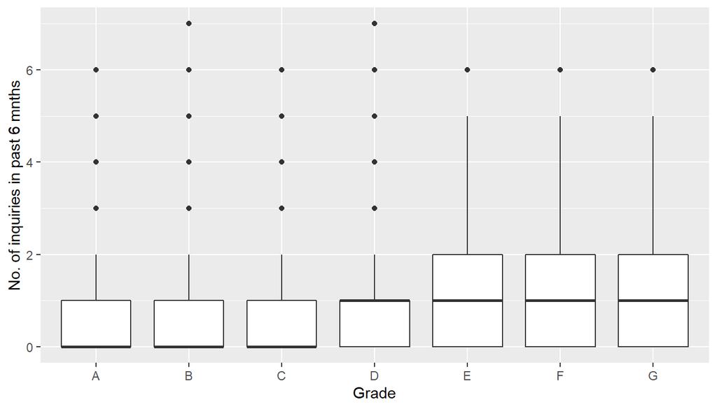

```r
ggplot(loan, aes(x= grade, y = inq_last_6mths)) + geom_boxplot()+
  labs(x = 'Grade', y = 'No. of inquiries in past 6 mnths')
```

### Number of inquiries in past 6 months and Interest Rate

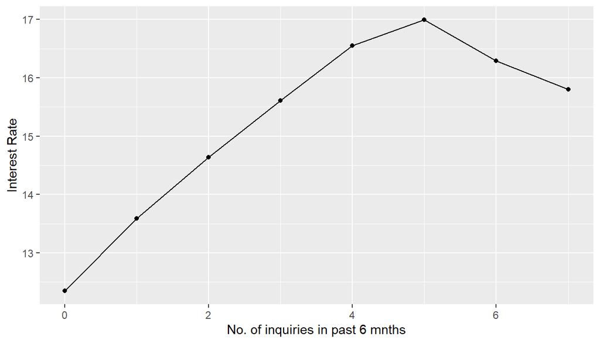

```r
inq_int<-loan%>%group_by(inq_last_6mths)%>%summarize('Mean'= mean(int_rate), 'Median' = median(int_rate))
ggplot(inq_int, aes(x=inq_last_6mths, y = Median))+geom_line()+geom_point()+
  labs(x = 'No. of inquiries in past 6 mnths', y = 'Interest Rate')
```

## Loan status prediction

```r
table(loan$loan_status)
```

```
##
##  Fully.Paid Charged.Off
##      549758      258015
```

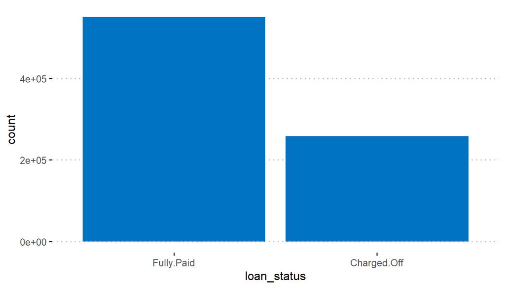

```r
ggplot(loan, aes(x=loan_status)) + geom_bar(stat='count', fill = "#0073C2FF") + theme_pubclean()
```

### Inference

#### From the plot, it can be observed that there is an imbalance in the dataset.

### Splitting into training and testing set

```r
set.seed(12)
tr_samples <-  loan$grade%>%
                 createDataPartition(p=0.8,list = FALSE)
train_data <- loan[tr_samples,]
test_data <- loan[-tr_samples,]
```

### Function for calculating accuracy, precision, recall and f1-score

```r
#error metrics -- Confusion Matrix
err_metric=function(CM)
{
  TN =CM[1,1]
  TP =CM[2,2]
  FP =CM[1,2]
  FN =CM[2,1]
  precision =(TP)/(TP+FP)
  recall_score =(TP)/(TP+FN)

  f1_score=2*((precision*recall_score)/(precision+recall_score))
  accuracy_model  =(TP+TN)/(TP+TN+FP+FN)
  False_positive_rate =(FP)/(FP+TN)
  False_negative_rate =(FN)/(FN+TP)

  print(paste("Precision value of the model: ",round(precision,2)))
  print(paste("Accuracy of the model: ",round(accuracy_model,2)))
  print(paste("Recall value of the model: ",round(recall_score,2)))
  print(paste("False Positive rate of the model: ",round(False_positive_rate,2)))

  print(paste("False Negative rate of the model: ",round(False_negative_rate,2)))

  print(paste("f1 score of the model: ",round(f1_score,2)))
  res <- c(accuracy_model ,precision, recall_score, f1_score)
  return(res)
}
```

### NOTE: In all the following models, class 0 represents fully paid loans or non-defaulters (not risky) and class 1 represents charged off loans or defaulters (risky).

## Logistic regression

### Model-1

```r
glm.model = glm(outcome ~ loan_amnt + term + int_rate + installment +  annual_inc + fico_range_low + grade + delinq_2yrs
                + tot_cur_bal + emp_length + inq_last_6mths + pub_rec,
                train_data, family = binomial(link = 'logit'))

summary(glm.model)
```

```
##
## Call:
## glm(formula = outcome ~ loan_amnt + term + int_rate + installment +
##     annual_inc + fico_range_low + grade + delinq_2yrs + tot_cur_bal +
##     emp_length + inq_last_6mths + pub_rec, family = binomial(link = "logit"),
##     data = train_data)
##
## Deviance Residuals:
##     Min       1Q   Median       3Q      Max
## -1.9749  -0.8859  -0.6331   1.1295   5.1345
##
## Coefficients:
##                       Estimate Std. Error z value Pr(>|z|)
## (Intercept)          6.493e-01  8.995e-02   7.218 5.27e-13 ***
## loan_amnt           -1.522e-05  2.407e-06  -6.324 2.54e-10 ***
## term                 2.762e-02  6.657e-04  41.489  < 2e-16 ***
## int_rate             2.844e-02  1.995e-03  14.255  < 2e-16 ***
## installment          9.127e-04  7.458e-05  12.239  < 2e-16 ***
## annual_inc          -1.208e-06  7.880e-08 -15.327  < 2e-16 ***
## fico_range_low      -4.831e-03  1.190e-04 -40.595  < 2e-16 ***
## gradeB               5.368e-01  1.395e-02  38.480  < 2e-16 ***
## gradeC               8.982e-01  1.788e-02  50.244  < 2e-16 ***
## gradeD               1.083e+00  2.397e-02  45.187  < 2e-16 ***
## gradeE               1.179e+00  3.047e-02  38.701  < 2e-16 ***
## gradeF               1.230e+00  3.922e-02  31.356  < 2e-16 ***
## gradeG               1.230e+00  5.052e-02  24.347  < 2e-16 ***
## delinq_2yrs          2.005e-02  3.086e-03   6.499 8.11e-11 ***
## tot_cur_bal         -1.190e-06  2.421e-08 -49.163  < 2e-16 ***
## emp_length< 1 year  -3.745e-01  1.470e-02 -25.468  < 2e-16 ***
## emp_length1 year    -3.878e-01  1.542e-02 -25.146  < 2e-16 ***
## emp_length10+ years -5.088e-01  1.207e-02 -42.166  < 2e-16 ***
## emp_length2 years   -4.306e-01  1.436e-02 -29.975  < 2e-16 ***
## emp_length3 years   -4.241e-01  1.475e-02 -28.745  < 2e-16 ***
## emp_length4 years   -4.377e-01  1.596e-02 -27.427  < 2e-16 ***
## emp_length5 years   -4.475e-01  1.581e-02 -28.299  < 2e-16 ***
## emp_length6 years   -4.718e-01  1.722e-02 -27.399  < 2e-16 ***
## emp_length7 years   -4.706e-01  1.738e-02 -27.073  < 2e-16 ***
## emp_length8 years   -4.280e-01  1.718e-02 -24.904  < 2e-16 ***
## emp_length9 years   -4.411e-01  1.816e-02 -24.288  < 2e-16 ***
## inq_last_6mths       6.368e-02  2.997e-03  21.244  < 2e-16 ***
## pub_rec              1.170e-02  4.521e-03   2.589  0.00963 **
## ---
## Signif. codes:  0 '***' 0.001 '**' 0.01 '*' 0.05 '.' 0.1 ' ' 1
##
## (Dispersion parameter for binomial family taken to be 1)
##
##     Null deviance: 809825  on 646221  degrees of freedom
## Residual deviance: 734395  on 646194  degrees of freedom
## AIC: 734451
##
## Number of Fisher Scoring iterations: 4
```

### Inference

#### All the features used in the model are significant as they have a p-value lower than 0.05.

### Importance

```r
imp <- varImp(glm.model)
imp%>%arrange(desc(Overall))
```

```
##                       Overall
## gradeC              50.243686
## tot_cur_bal         49.162669
## gradeD              45.187433
## emp_length10+ years 42.166494
## term                41.489421
## fico_range_low      40.595127
## gradeE              38.701167
## gradeB              38.480231
## gradeF              31.356475
## emp_length2 years   29.975425
## emp_length3 years   28.745001
## emp_length5 years   28.299145
## emp_length4 years   27.427267
## emp_length6 years   27.399371
## emp_length7 years   27.073195
## emp_length< 1 year  25.467996
## emp_length1 year    25.145809
## emp_length8 years   24.904440
## gradeG              24.347277
## emp_length9 years   24.287673
## inq_last_6mths      21.243926
## annual_inc          15.327466
## int_rate            14.254551
## installment         12.238581
## delinq_2yrs          6.498537
## loan_amnt            6.324247
## pub_rec              2.588890
```

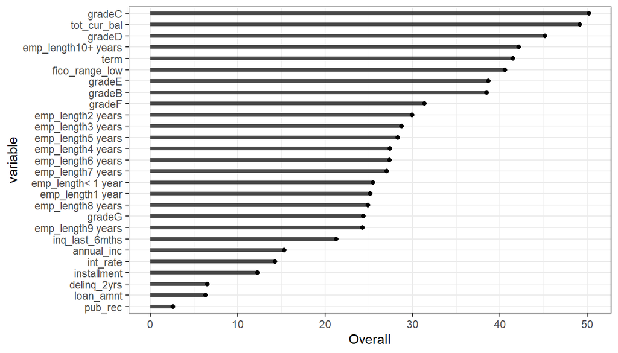

```r
imp <- imp%>%mutate(variable = rownames(imp))

imp2 <- imp %>%
  arrange(Overall) %>%
  mutate(variable = forcats::fct_inorder(variable))

ggplot(imp2) +
  geom_point(aes(x = variable, y = Overall), col = "black", show.legend = F) +
  geom_segment(aes(x = variable, y = 0, xend = variable, yend = Overall), size = 1.5, alpha = 0.7) +
  coord_flip() +
  scale_fill_grey() +
  theme_bw()
```

### Inference

#### From the above plot, it can be observed that grade, total current balance, employment lenght, term and fico score are the top most important features used by the logistic regression model to predict loan defaulters.

### Outliers

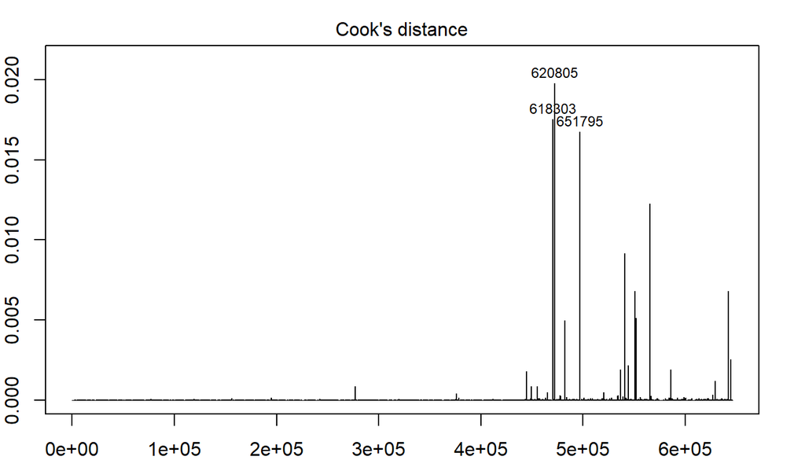

```r
par(mar=c(2,2,2,2))
plot(glm.model,4)
```

```r
model_data <- augment(glm.model) %>%
              mutate(index=1:n())


model_data%>%top_n(3,.cooksd)
```

```
## # A tibble: 3 x 21
##   .rownames outcome loan_amnt  term int_rate installment annual_inc
##   <chr>     <fct>       <int> <dbl>    <dbl>       <dbl>      <dbl>
## 1 618303    1           10550    36    15.6         369.    8900060
## 2 620805    1           24000    60     7.89        485.    9500000
## 3 651795    1            8000    36    13.7         272.    8706582
## # ... with 14 more variables: fico_range_low <int>, grade <fct>,
## #   delinq_2yrs <int>, tot_cur_bal <dbl>, emp_length <fct>,
## #   inq_last_6mths <int>, pub_rec <int>, .fitted <dbl>, .resid <dbl>,
## #   .std.resid <dbl>, .hat <dbl>, .sigma <dbl>, .cooksd <dbl>, index <int>
```

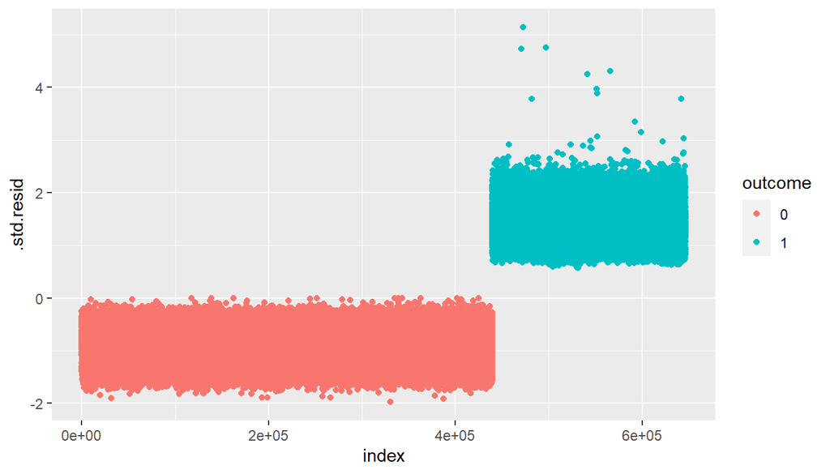

```r
ggplot(model_data,aes(index,.std.resid))+geom_point(aes(col=outcome))
```

```r
model_data %>% filter(abs(.std.resid)>3)
```

```
## # A tibble: 13 x 21
##    .rownames outcome loan_amnt  term int_rate installment annual_inc
##    <chr>     <fct>       <int> <dbl>    <dbl>       <dbl>      <dbl>
##  1 618303    1           10550    36    15.6        369.     8900060
##  2 620805    1           24000    60     7.89       485.     9500000
##  3 632830    1           15000    36     8.18       471.     4800000
##  4 651795    1            8000    36    13.7        272.     8706582
##  5 706622    1           25000    60     8.39       512.     6500000
##  6 719148    1           12800    36    11.5        422.     5604824
##  7 720332    1            6000    36     9.17       191.     4860012
##  8 720684    1           20000    36     5.32       602.      650000
##  9 737699    1           15000    36    19.5        554.     7500000
## 10 776752    1           40000    36     8.24      1258.      724458
## 11 784703    1           35000    36    14.3       1201.      400000
## 12 843365    1           15000    36    16.0        527.     5588951
## 13 846507    1            1500    36    14.0         51.3    3437892
## # ... with 14 more variables: fico_range_low <int>, grade <fct>,
## #   delinq_2yrs <int>, tot_cur_bal <dbl>, emp_length <fct>,
## #   inq_last_6mths <int>, pub_rec <int>, .fitted <dbl>, .resid <dbl>,
## #   .std.resid <dbl>, .hat <dbl>, .sigma <dbl>, .cooksd <dbl>, index <int>
```

### Inference

#### Around 13 rows have a standard deviation greater than 3. This is quite low when compared to the total number of rows in the dataset, hence can be ignored.

### Multicollinearity

```r
vif(glm.model)
```

```
##                     GVIF Df GVIF^(1/(2*Df))
## loan_amnt      56.379788  1        7.508648
## term            6.878829  1        2.622752
## int_rate       10.904108  1        3.302137
## installment    48.438568  1        6.959782
## annual_inc      1.557634  1        1.248052
## fico_range_low  1.296965  1        1.138844
## grade          10.916550  6        1.220414
## delinq_2yrs     1.040359  1        1.019980
## tot_cur_bal     1.353016  1        1.163192
## emp_length      1.053534 11        1.002373
## inq_last_6mths  1.067841  1        1.033364
## pub_rec         1.051117  1        1.025240
```

### ROC curve

```r
preds = predict(glm.model , test_data , type = 'response')

roc_glm1 <- roc(response = test_data$outcome, predictor = preds)
roc_glm1
```

```
##
## Call:
## roc.default(response = test_data$outcome, predictor = preds)
##
## Data: preds in 110083 controls (test_data$outcome 0) < 51468 cases (test_data$outcome 1).
## Area under the curve: 0.7037
```

```r
coords(roc_glm1, "best", ret = "threshold", transpose = TRUE)
```

```
## threshold
## 0.3230093
```

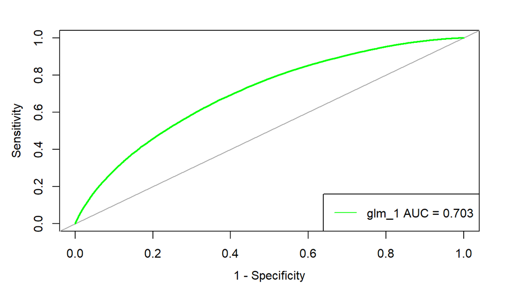

```r
plot.roc(x = roc_glm1, legacy.axes = TRUE, xlim = c(1, 0), asp = NA,
               col = "green", print.auc = FALSE, print.auc.y = .4)
legend(x = "bottomright", legend=c("glm_1 AUC = 0.703"),
       col = c("green"), lty = 1, cex = 1.0)
```

### Inference

#### Sensitivity is the true positive rate and 1 - specificity is the false positive rate.

#### Although false positive rate must be low, it might be useful to allow false positives when finding the positives is very important. Similarly, in some cases it might be really important to keep false positives as minimum as possible even if it means the true positives will be less.

#### ROC will help decide what threshold to choose.

#### In this case, the threshold should be around 0.32, in order to obtain an even trade-off between sensitivity and specificity.

#### It can be adjusted based on the requirements. In order to catch more defaulters the threshold could be reduced, however, this could lead to higher false positive rate. Hence, reducing the chances of making investments as most loans would be classified as risky.

#### Similarly to increase investments the threshold could be increased, however, this could lead to higher false negative rate. Hence, increasing the chances of making risky investments.

### Confusion matrix

```r
pred.cls <- factor(ifelse(preds > 0.3225452  , 1 , 0), levels = c(0,1))
confusionMatrix(pred.cls, test_data$outcome)
```

```
## Confusion Matrix and Statistics
##
##           Reference
## Prediction     0     1
##          0 69037 17116
##          1 41046 34352
##
##                Accuracy : 0.64
##                  95% CI : (0.6376, 0.6423)
##     No Information Rate : 0.6814
##     P-Value [Acc > NIR] : 1
##
##                   Kappa : 0.2621
##
##  Mcnemar's Test P-Value : <2e-16
##
##             Sensitivity : 0.6271
##             Specificity : 0.6674
##          Pos Pred Value : 0.8013
##          Neg Pred Value : 0.4556
##              Prevalence : 0.6814
##          Detection Rate : 0.4273
##    Detection Prevalence : 0.5333
##       Balanced Accuracy : 0.6473
##
##        'Positive' Class : 0
##
```

### Inference

#### The model achieved an accuracy of 64%.

```r
CM= table(test_data$outcome, pred.cls)
res = err_metric(CM)
```

```
## [1] "Precision value of the model:  0.46"
## [1] "Accuracy of the model:  0.64"
## [1] "Recall value of the model:  0.67"
## [1] "False Positive rate of the model:  0.37"
## [1] "False Negative rate of the model:  0.33"
## [1] "f1 score of the model:  0.54"
```

### Inference

#### From the precision and recall, we can say that this model is 46% accurate when predicting defaulters and catches 67% of the defaulters.

#### Model-2 (with cross-validation)

```r
ctrl <- trainControl(method = "repeatedcv",
               number = 10,
               repeats = 5,
               classProbs = TRUE,
               summaryFunction = twoClassSummary,
               savePredictions = TRUE,
               verboseIter = FALSE)

glm.model2 <- train(make.names(outcome) ~ loan_amnt+ installment +term + int_rate +
                      annual_inc + fico_range_low + grade + delinq_2yrs + tot_cur_bal + emp_length + inq_last_6mths + pub_rec,
                train_data,
                method = "glm",
                family = "binomial",
                metric = "ROC",
                trControl = ctrl)
```

#### Model details

```r
glm.model2
```

```
## Generalized Linear Model
##
## 646222 samples
##     12 predictor
##      2 classes: 'X0', 'X1'
##
## No pre-processing
## Resampling: Cross-Validated (10 fold, repeated 5 times)
## Summary of sample sizes: 581601, 581599, 581600, 581601, 581599, 581599, ...
## Resampling results:
##
##   ROC        Sens       Spec
##   0.7046548  0.9119668  0.2642798
```

#### Model summary

```r
summary(glm.model2)
```

```
##
## Call:
## NULL
##
## Deviance Residuals:
##     Min       1Q   Median       3Q      Max
## -1.9749  -0.8859  -0.6331   1.1295   5.1345
##
## Coefficients:
##                         Estimate Std. Error z value Pr(>|z|)
## (Intercept)            6.493e-01  8.995e-02   7.218 5.27e-13 ***
## loan_amnt             -1.522e-05  2.407e-06  -6.324 2.54e-10 ***
## installment            9.127e-04  7.458e-05  12.239  < 2e-16 ***
## term                   2.762e-02  6.657e-04  41.489  < 2e-16 ***
## int_rate               2.844e-02  1.995e-03  14.255  < 2e-16 ***
## annual_inc            -1.208e-06  7.880e-08 -15.327  < 2e-16 ***
## fico_range_low        -4.831e-03  1.190e-04 -40.595  < 2e-16 ***
## gradeB                 5.368e-01  1.395e-02  38.480  < 2e-16 ***
## gradeC                 8.982e-01  1.788e-02  50.244  < 2e-16 ***
## gradeD                 1.083e+00  2.397e-02  45.187  < 2e-16 ***
## gradeE                 1.179e+00  3.047e-02  38.701  < 2e-16 ***
## gradeF                 1.230e+00  3.922e-02  31.356  < 2e-16 ***
## gradeG                 1.230e+00  5.052e-02  24.347  < 2e-16 ***
## delinq_2yrs            2.005e-02  3.086e-03   6.499 8.11e-11 ***
## tot_cur_bal           -1.190e-06  2.421e-08 -49.163  < 2e-16 ***
## `emp_length< 1 year`  -3.745e-01  1.470e-02 -25.468  < 2e-16 ***
## `emp_length1 year`    -3.878e-01  1.542e-02 -25.146  < 2e-16 ***
## `emp_length10+ years` -5.088e-01  1.207e-02 -42.166  < 2e-16 ***
## `emp_length2 years`   -4.306e-01  1.436e-02 -29.975  < 2e-16 ***
## `emp_length3 years`   -4.241e-01  1.475e-02 -28.745  < 2e-16 ***
## `emp_length4 years`   -4.377e-01  1.596e-02 -27.427  < 2e-16 ***
## `emp_length5 years`   -4.475e-01  1.581e-02 -28.299  < 2e-16 ***
## `emp_length6 years`   -4.718e-01  1.722e-02 -27.399  < 2e-16 ***
## `emp_length7 years`   -4.706e-01  1.738e-02 -27.073  < 2e-16 ***
## `emp_length8 years`   -4.280e-01  1.718e-02 -24.904  < 2e-16 ***
## `emp_length9 years`   -4.411e-01  1.816e-02 -24.288  < 2e-16 ***
## inq_last_6mths         6.368e-02  2.997e-03  21.244  < 2e-16 ***
## pub_rec                1.170e-02  4.521e-03   2.589  0.00963 **
## ---
## Signif. codes:  0 '***' 0.001 '**' 0.01 '*' 0.05 '.' 0.1 ' ' 1
##
## (Dispersion parameter for binomial family taken to be 1)
##
##     Null deviance: 809825  on 646221  degrees of freedom
## Residual deviance: 734395  on 646194  degrees of freedom
## AIC: 734451
##
## Number of Fisher Scoring iterations: 4
```

### Inference

#### 10-fold cross validation is performed in this logistic regression model.

### Importance

```r
varImp(glm.model2)
```

```
## glm variable importance
##
##   only 20 most important variables shown (out of 27)
##
##                       Overall
## gradeC                 100.00
## tot_cur_bal             97.73
## gradeD                  89.39
## `emp_length10+ years`   83.05
## term                    81.63
## fico_range_low          79.75
## gradeE                  75.78
## gradeB                  75.32
## gradeF                  60.37
## `emp_length2 years`     57.47
## `emp_length3 years`     54.89
## `emp_length5 years`     53.95
## `emp_length4 years`     52.12
## `emp_length6 years`     52.06
## `emp_length7 years`     51.38
## `emp_length< 1 year`    48.01
## `emp_length1 year`      47.33
## `emp_length8 years`     46.83
## gradeG                  45.66
## `emp_length9 years`     45.53
```

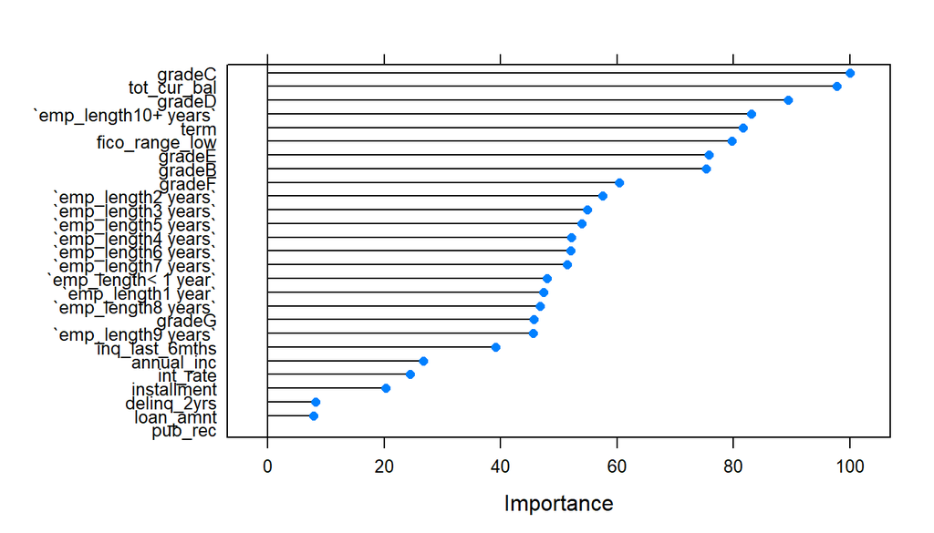

```r
plot(varImp(glm.model2))
```

### Inference

#### From the above plot, it can be observed that the results are similar to the previous movel; grade, total current balance, employment lenght, term and fico score are the top most important features used by this logistic regression model as well to predict loan defaulters.

### ROC curve

```r
preds = predict(glm.model2 , test_data , type = 'prob')
preds <- as.data.frame(preds)
colnames(preds) <- c("0","1")

roc_glm2 <- roc(response = test_data$outcome, predictor = preds[["1"]])
roc_glm2
```

```
##
## Call:
## roc.default(response = test_data$outcome, predictor = preds[["1"]])
##
## Data: preds[["1"]] in 110083 controls (test_data$outcome 0) < 51468 cases (test_data$outcome 1).
## Area under the curve: 0.7037
```

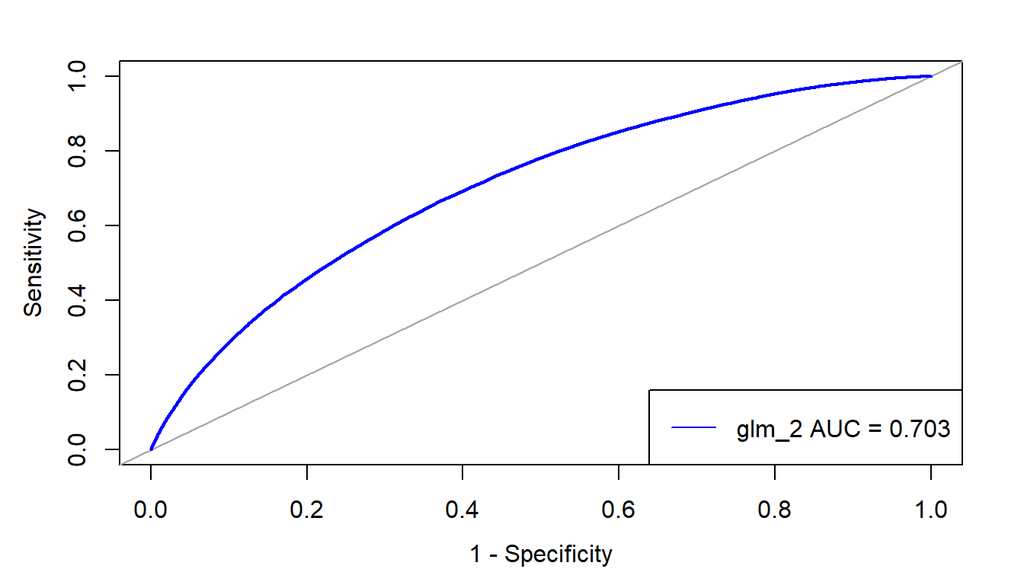

```r
plot.roc(x = roc_glm2, legacy.axes = TRUE, xlim = c(1, 0), asp = NA,
               col = "blue", print.auc = FALSE, print.auc.y = .4)

legend(x = "bottomright", legend=c("glm_2 AUC = 0.703"),
       col = c("blue"), lty = 1, cex = 1.0)
```

```r
coords(roc_glm2, "best", ret = "threshold", transpose = TRUE)
```

```
## threshold
## 0.3230093
```

#### Confusion matrix

```r
pred.cls <- apply(preds, 1, function(x) ifelse(x["1"] >= 0.35, 1, 0))
confusionMatrix(as.factor(pred.cls), test_data$outcome)
```

```
## Confusion Matrix and Statistics
##
##           Reference
## Prediction     0     1
##          0 76394 20885
##          1 33689 30583
##
##                Accuracy : 0.6622
##                  95% CI : (0.6599, 0.6645)
##     No Information Rate : 0.6814
##     P-Value [Acc > NIR] : 1
##
##                   Kappa : 0.2703
##
##  Mcnemar's Test P-Value : <2e-16
##
##             Sensitivity : 0.6940
##             Specificity : 0.5942
##          Pos Pred Value : 0.7853
##          Neg Pred Value : 0.4758
##              Prevalence : 0.6814
##          Detection Rate : 0.4729
##    Detection Prevalence : 0.6022
##       Balanced Accuracy : 0.6441
##
##        'Positive' Class : 0
##
```

### Inference

#### The model achieved an accuracy of 66%.

```r
CM= table( test_data$outcome, as.factor(pred.cls))
res = err_metric(CM)
```

```
## [1] "Precision value of the model:  0.48"
## [1] "Accuracy of the model:  0.66"
## [1] "Recall value of the model:  0.59"
## [1] "False Positive rate of the model:  0.31"
## [1] "False Negative rate of the model:  0.41"
## [1] "f1 score of the model:  0.53"
```

```r
res <- round(res, digits = 2)
```

#### Inference

##### From the precision and recall, we can say that this model is 48% accurate when predicting defaulters and catches 59% of the defaulters.

### Table

```r
com_df <- data.frame("Algorithm" = c("Logistic regression"),
                     "Accuracy" = res[1],
                     "Precision" = res[2],
                     "Recall" = res[3],
                     "F1-score" = res[4])

kable(com_df)
```

| Algorithm | Accuracy | Precision | Recall | F1.score |
| --- | --- | --- | --- | --- |
| Logistic regression | 0.66 | 0.48 | 0.59 | 0.53 |

### Decision tree

```r
ctrl <- rpart.control( cp = 0.0001)
dt.model = rpart(outcome ~ loan_amnt + term + int_rate + installment +  annual_inc + fico_range_low + grade + delinq_2yrs
                + tot_cur_bal + emp_length + inq_last_6mths + pub_rec,
                train_data, method = 'class', control = ctrl)
```

#### Importance

```r
imp_dt <- varImp(dt.model)

imp_dt%>%arrange(desc(Overall))
```

```
##                    Overall
## grade          24838.81789
## int_rate       23689.70267
## term           17011.80366
## fico_range_low  5674.90082
## tot_cur_bal     4123.91631
## loan_amnt       3728.87220
## installment     3435.09380
## annual_inc      1217.55891
## emp_length       924.74306
## inq_last_6mths   118.37943
## pub_rec           56.40116
## delinq_2yrs       22.24891
```

#### ROC curve

```r
preds = predict(dt.model , test_data , type = 'prob')

roc_rpart <- preds[,"1"]

roc_rpart <- roc(response = test_data$outcome, predictor = roc_rpart)
roc_rpart
```

```
##
## Call:
## roc.default(response = test_data$outcome, predictor = roc_rpart)
##
## Data: roc_rpart in 110083 controls (test_data$outcome 0) < 51468 cases (test_data$outcome 1).
## Area under the curve: 0.6785
```

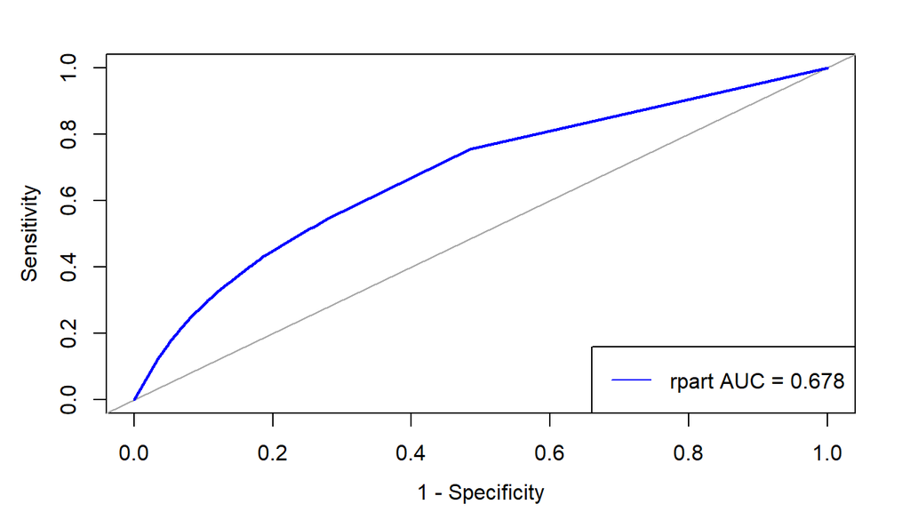

```r
plot.roc(x = roc_rpart, legacy.axes = TRUE, xlim = c(1, 0), asp = NA,
               col = "blue", print.auc = FALSE, print.auc.y = .4)

legend(x = "bottomright", legend=c("rpart AUC = 0.678"),
       col = c("blue"), lty = 1, cex = 1.0)
```

```r
coords(roc_rpart, "best", ret = "threshold", transpose = TRUE)
```

```
## threshold
## 0.2533765
```

#### Inference

##### The threshold should be around 0.25, in order to obtain an even trade-off between sensitivity and specificity.

#### Confusion matrix

```r
preds = predict(dt.model , test_data , type = 'class')
pred.cls <- factor(preds, levels = c(0,1))
confusionMatrix(pred.cls, test_data$outcome)
```

```
## Confusion Matrix and Statistics
##
##           Reference
## Prediction     0     1
##          0 99651 37336
##          1 10432 14132
##
##                Accuracy : 0.7043
##                  95% CI : (0.7021, 0.7065)
##     No Information Rate : 0.6814
##     P-Value [Acc > NIR] : < 2.2e-16
##
##                   Kappa : 0.2089
##
##  Mcnemar's Test P-Value : < 2.2e-16
##
##             Sensitivity : 0.9052
##             Specificity : 0.2746
##          Pos Pred Value : 0.7274
##          Neg Pred Value : 0.5753
##              Prevalence : 0.6814
##          Detection Rate : 0.6168
##    Detection Prevalence : 0.8479
##       Balanced Accuracy : 0.5899
##
##        'Positive' Class : 0
##
```

### Inference

#### The model achieved an accuracy of 70%.

```r
CM= table( test_data$outcome, pred.cls)
res = err_metric(CM)
```

```
## [1] "Precision value of the model:  0.58"
## [1] "Accuracy of the model:  0.7"
## [1] "Recall value of the model:  0.27"
## [1] "False Positive rate of the model:  0.09"
## [1] "False Negative rate of the model:  0.73"
## [1] "f1 score of the model:  0.37"
```

#### Inference

##### From the precision and recall, we can say that this model is 58% accurate when predicting defaulters and catches 27% of the defaulters.

### Table

```r
res = round(res, digits = 2)
com_df <- rbind(com_df, c("Decision tree", res[1], res[2], res[3], res[4]))
kable(com_df)
```

| Algorithm | Accuracy | Precision | Recall | F1.score |
| --- | --- | --- | --- | --- |
| Logistic regression | 0.66 | 0.48 | 0.59 | 0.53 |
| Decision tree | 0.7 | 0.58 | 0.27 | 0.37 |

#### Inference

##### Based on f1-score, logistic regression is the better model.

### Naive bayes

```r
nv.model <- naiveBayes(outcome ~ application_type+emp_length+issue_mon+issue_yr+term+grade,data=train_data)
```

##### Probability by the model

```r
nv.model
```

```
##
## Naive Bayes Classifier for Discrete Predictors
##
## Call:
## naiveBayes.default(x = X, y = Y, laplace = laplace)
##
## A-priori probabilities:
## Y
##         0         1
## 0.6803776 0.3196224
##
## Conditional probabilities:
##    application_type
## Y   Individual  Joint App
##   0 0.98118610 0.01881390
##   1 0.97582633 0.02417367
##
##    emp_length
## Y                < 1 year     1 year  10+ years    2 years    3 years
##   0 0.05451527 0.07807585 0.06415875 0.33959857 0.09029397 0.08007960
##   1 0.07916842 0.08192808 0.06720504 0.31168209 0.09003762 0.08010768
##    emp_length
## Y      4 years    5 years    6 years    7 years    8 years    9 years
##   0 0.05875476 0.06114289 0.04585660 0.04421448 0.04530164 0.03800762
##   1 0.05838865 0.06039303 0.04446930 0.04318146 0.04549086 0.03794778
##
##    issue_mon
## Y          Apr        Aug        Dec        Feb        Jan        Jul
##   0 0.08020697 0.08123728 0.07853756 0.07931768 0.08512879 0.09449707
##   1 0.08490077 0.08319172 0.07801614 0.07369267 0.08037396 0.09773078
##    issue_mon
## Y          Jun        Mar        May        Nov        Oct        Sep
##   0 0.07222608 0.09416501 0.07578552 0.08625007 0.10499801 0.06764997
##   1 0.07598755 0.09500501 0.08012220 0.08286734 0.09907672 0.06903513
##
##    issue_yr
## Y         2007       2008       2009       2010       2011       2012
##   0 0.00000000 0.00000000 0.00000000 0.00000000 0.00000000 0.02145676
##   1 0.00000000 0.00000000 0.00000000 0.00000000 0.00000000 0.01548316
##    issue_yr
## Y         2013       2014       2015       2016       2017       2018
##   0 0.11122761 0.17814295 0.29374197 0.22044465 0.12864275 0.04634332
##   1 0.08178284 0.15945523 0.29321656 0.26377047 0.15178143 0.03451031
##
##    term
## Y       [,1]      [,2]
##   0 40.86867  9.651131
##   1 45.41969 11.719328
##
##    grade
## Y             A           B           C           D           E           F
##   0 0.201528402 0.314891681 0.279526923 0.130528231 0.053473588 0.015861716
##   1 0.050647068 0.192871356 0.322246268 0.228732443 0.134511758 0.054074859
##    grade
## Y             G
##   0 0.004189458
##   1 0.016916247
```

#### ROC curve

```r
preds = predict(nv.model , test_data , type = 'raw')
prob_nv <- preds[,"1"]
```

```r
roc_nv <- roc(response = test_data$outcome, predictor = prob_nv)
roc_nv
```

```
##
## Call:
## roc.default(response = test_data$outcome, predictor = prob_nv)
##
## Data: prob_nv in 110083 controls (test_data$outcome 0) < 51468 cases (test_data$outcome 1).
## Area under the curve: 0.6938
```

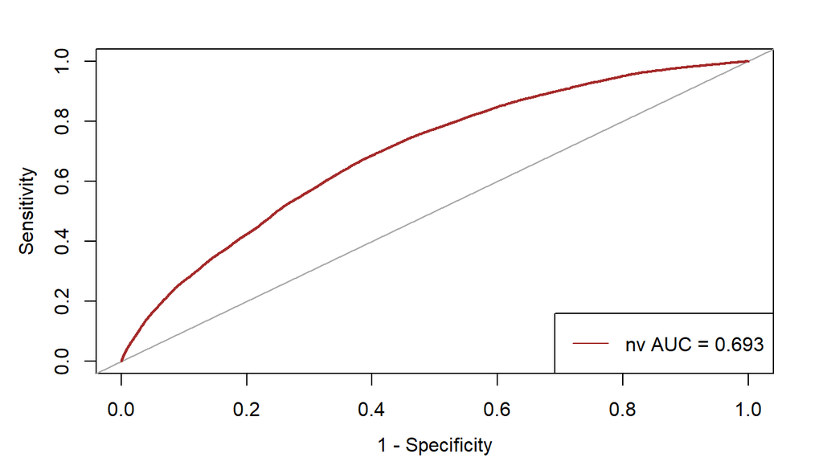

```r
plot.roc(x = roc_nv, legacy.axes = TRUE, xlim = c(1, 0), asp = NA,
               col = "brown", print.auc = FALSE, print.auc.y = .4)

legend(x = "bottomright", legend=c("nv AUC = 0.693"),
       col = c("brown"), lty = 1, cex = 1.0)
```

```r
coords(roc_nv, "best", ret = "threshold", transpose = TRUE)
```

```
## threshold
## 0.2838629
```

#### Inference

##### The threshold should be around 0.28, in order to obtain an even trade-off between sensitivity and specificity.

#### Confusion matrix

```r
pred <- nv.model %>% predict(test_data)
mean(pred == test_data$outcome)
```

```
## [1] 0.6865572
```

```r
confusionMatrix(pred, test_data$outcome)
```

```
## Confusion Matrix and Statistics
##
##           Reference
## Prediction     0     1
##          0 91410 31964
##          1 18673 19504
##
##                Accuracy : 0.6866
##                  95% CI : (0.6843, 0.6888)
##     No Information Rate : 0.6814
##     P-Value [Acc > NIR] : 4.481e-06
##
##                   Kappa : 0.2248
##
##  Mcnemar's Test P-Value : < 2.2e-16
##
##             Sensitivity : 0.8304
##             Specificity : 0.3790
##          Pos Pred Value : 0.7409
##          Neg Pred Value : 0.5109
##              Prevalence : 0.6814
##          Detection Rate : 0.5658
##    Detection Prevalence : 0.7637
##       Balanced Accuracy : 0.6047
##
##        'Positive' Class : 0
##
```

### Inference

#### The model achieved an accuracy of 69%.

```r
CM= table( test_data$outcome,pred)
res = err_metric(CM)
```

```
## [1] "Precision value of the model:  0.51"
## [1] "Accuracy of the model:  0.69"
## [1] "Recall value of the model:  0.38"
## [1] "False Positive rate of the model:  0.17"
## [1] "False Negative rate of the model:  0.62"
## [1] "f1 score of the model:  0.44"
```

#### Inference

##### From the precision and recall, we can say that this model is 51% accurate when predicting defaulters and catches 38% of the defaulters.

### Table

```r
res = round(res, digits = 2)
com_df <- rbind(com_df, c("Naive bayes", res[1], res[2], res[3], res[4]))
kable(com_df)
```

| Algorithm | Accuracy | Precision | Recall | F1.score |
| --- | --- | --- | --- | --- |
| Logistic regression | 0.66 | 0.48 | 0.59 | 0.53 |
| Decision tree | 0.7 | 0.58 | 0.27 | 0.37 |
| Naive bayes | 0.69 | 0.51 | 0.38 | 0.44 |

#### Inference

##### Based on f1-score, logistic regression is the better model.

### Random forest

```r
tr_data <- sample_n(train_data, 200000)
model <- randomForest(outcome ~ loan_amnt + term + int_rate + installment +  annual_inc + fico_range_low + grade + delinq_2yrs
                      + acc_now_delinq + emp_length + pub_rec + inq_last_6mths,
                data = tr_data,
                method="rf",
                importance = TRUE)
```

### Importance of predictors

```r
importance(model)
```

```
##                        0          1 MeanDecreaseAccuracy MeanDecreaseGini
## loan_amnt      76.955549 -34.331029            88.334517        8634.4595
## term           65.574828  15.890937            86.991688        1402.8134
## int_rate       42.228759  27.661340            53.275836       12462.3655
## installment    76.977057 -33.755426            88.952802       12380.1653
## annual_inc     47.993597  23.250235            61.855851       12591.6637
## fico_range_low 71.332383   3.863223            70.918530        7834.2948
## grade          35.859141  24.133346            49.072387        4141.5743
## delinq_2yrs    26.340059  -3.140733            21.362822        2638.2598
## acc_now_delinq  4.070806  -1.431139             2.676796         154.1545
## emp_length     18.601454   4.308569            17.626865        7953.6277
## pub_rec        44.411457 -14.096393            33.077268        1992.5068
## inq_last_6mths 36.359394   2.215219            31.557886        3351.0040
```

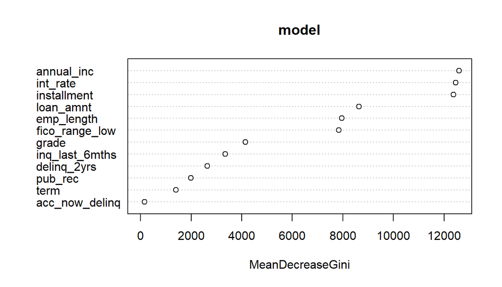

```r
varImpPlot(model,type=2)
```

### Inference

#### From the plot, it can be observed that annual income, installment, interest rate, loan amount and employment length are the 5 top most important features used by random forest when predicting defaulters.

### ROC curve

```r
preds = predict(model , test_data , type = 'prob')
prob_rf <- preds[,"1"]

roc_rf <- roc(response = test_data$outcome, predictor = prob_rf)
roc_rf
```

```
##
## Call:
## roc.default(response = test_data$outcome, predictor = prob_rf)
##
## Data: prob_rf in 110083 controls (test_data$outcome 0) < 51468 cases (test_data$outcome 1).
## Area under the curve: 0.6871
```

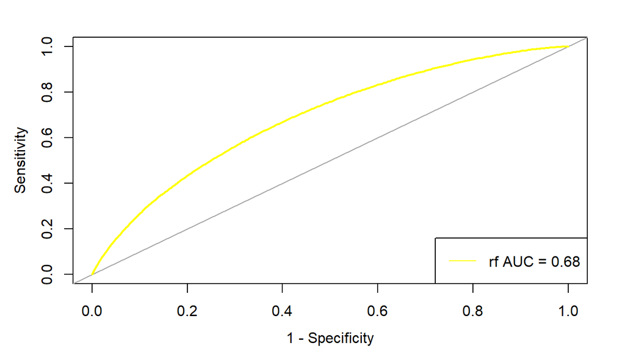

```r
plot.roc(x = roc_rf, legacy.axes = TRUE, xlim = c(1, 0), asp = NA,
               col = "yellow", print.auc = FALSE, print.auc.y = .4)

legend(x = "bottomright", legend=c("rf AUC = 0.68"),
       col = c("yellow"), lty = 1, cex = 1.0)
```

```r
coords(roc_rf, "best", ret = "threshold", transpose = TRUE)
```

```
## threshold
##     0.299
```

### Inference

#### The threshold should be around 0.29, in order to obtain an even trade-off between sensitivity and specificity.

#### Confusion matrix

```r
pred <- model %>% predict(test_data)
mean(pred == test_data$outcome)
```

```
## [1] 0.6970864
```

```r
confusionMatrix(pred, test_data$outcome)
```

```
## Confusion Matrix and Statistics
##
##           Reference
## Prediction     0     1
##          0 96837 35690
##          1 13246 15778
##
##                Accuracy : 0.6971
##                  95% CI : (0.6948, 0.6993)
##     No Information Rate : 0.6814
##     P-Value [Acc > NIR] : < 2.2e-16
##
##                   Kappa : 0.2107
##
##  Mcnemar's Test P-Value : < 2.2e-16
##
##             Sensitivity : 0.8797
##             Specificity : 0.3066
##          Pos Pred Value : 0.7307
##          Neg Pred Value : 0.5436
##              Prevalence : 0.6814
##          Detection Rate : 0.5994
##    Detection Prevalence : 0.8203
##       Balanced Accuracy : 0.5931
##
##        'Positive' Class : 0
##
```

### Inference

#### The model achieved an accuracy of 70%.

```r
CM= table( test_data$outcome,pred)
res =err_metric(CM)
```

```
## [1] "Precision value of the model:  0.54"
## [1] "Accuracy of the model:  0.7"
## [1] "Recall value of the model:  0.31"
## [1] "False Positive rate of the model:  0.12"
## [1] "False Negative rate of the model:  0.69"
## [1] "f1 score of the model:  0.39"
```

#### Inference

##### From the precision and recall, we can say that this model is 54% accurate when predicting defaulters and catches 31% of the defaulters.

### Table

```r
res = round(res, digits = 2)
com_df <- rbind(com_df, c("Random forest", res[1], res[2], res[3], res[4]))
kable(com_df)
```

| Algorithm | Accuracy | Precision | Recall | F1.score |
| --- | --- | --- | --- | --- |
| Logistic regression | 0.66 | 0.48 | 0.59 | 0.53 |
| Decision tree | 0.7 | 0.58 | 0.27 | 0.37 |
| Naive bayes | 0.69 | 0.51 | 0.38 | 0.44 |
| Random forest | 0.7 | 0.54 | 0.31 | 0.39 |

#### Inference

##### Based on f1-score, logistic regression is the better model.

### SVM

```r
tr_data <- sample_n(train_data, 20000)

tr_data <- tr_data%>%dplyr::select("loan_amnt","outcome", "term", "pub_rec", "fico_range_high", "int_rate",
                            "inq_last_6mths", "acc_now_delinq", "installment", "annual_inc", "fico_range_low", "delinq_2yrs")



svm_model = svm(outcome~.,data=tr_data,
                type='C-classification',
                kernel="radial",
              cost=10,
              probability=TRUE,
              gamma= 1)
```

#### NOTE: The SVM model is trained on a smaller dataset with only numerical values.

#### ROC curve

```r
ts_data <- test_data%>%dplyr::select("loan_amnt","outcome", "term", "pub_rec", "fico_range_high", "int_rate",
                            "inq_last_6mths", "acc_now_delinq", "installment", "annual_inc", "fico_range_low", "delinq_2yrs")


pred_svm <- predict(svm_model, ts_data, probability = TRUE)
```

```r
prob_svm <- attr(pred_svm, "probabilities")[,2]

roc_svm <- roc(response = ts_data$outcome, predictor = prob_svm)
roc_svm
```

```
##
## Call:
## roc.default(response = ts_data$outcome, predictor = prob_svm)
##
## Data: prob_svm in 110083 controls (ts_data$outcome 0) < 51468 cases (ts_data$outcome 1).
## Area under the curve: 0.6027
```

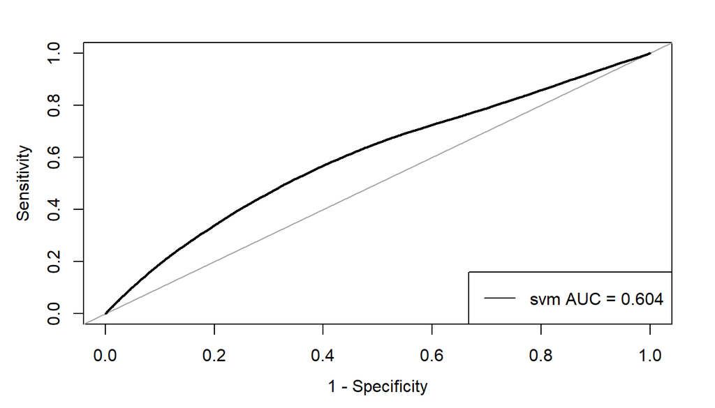

```r
plot.roc(x = roc_svm, legacy.axes = TRUE, xlim = c(1, 0), asp = NA,
               col = "black", print.auc = FALSE, print.auc.y = .4)

legend(x = "bottomright", legend=c("svm AUC = 0.604"),
       col = c("black"), lty = 1, cex = 1.0)
```

```r
coords(roc_svm, "best", ret = "threshold", transpose = TRUE)
```

```
## threshold
## 0.3106216
```

#### Inference

##### The threshold should be around 0.31, in order to obtain an even trade-off between sensitivity and specificity.

#### Confusion Matrix

```r
confusionMatrix(as.factor(pred_svm), test_data$outcome)
```

```
## Confusion Matrix and Statistics
##
##           Reference
## Prediction      0      1
##          0 108053  49411
##          1   2030   2057
##
##                Accuracy : 0.6816
##                  95% CI : (0.6793, 0.6839)
##     No Information Rate : 0.6814
##     P-Value [Acc > NIR] : 0.4439
##
##                   Kappa : 0.0285
##
##  Mcnemar's Test P-Value : <2e-16
##
##             Sensitivity : 0.98156
##             Specificity : 0.03997
##          Pos Pred Value : 0.68621
##          Neg Pred Value : 0.50330
##              Prevalence : 0.68141
##          Detection Rate : 0.66885
##    Detection Prevalence : 0.97470
##       Balanced Accuracy : 0.51076
##
##        'Positive' Class : 0
##
```

### Inference

#### The model achieved an accuracy of 68%.

```r
CM= table( test_data$outcome,pred_svm)
res = err_metric(CM)
```

```
## [1] "Precision value of the model:  0.5"
## [1] "Accuracy of the model:  0.68"
## [1] "Recall value of the model:  0.04"
## [1] "False Positive rate of the model:  0.02"
## [1] "False Negative rate of the model:  0.96"
## [1] "f1 score of the model:  0.07"
```

#### Inference

##### From the precision and recall, we can say that this model is 50% accurate when predicting defaulters and catches 4% of the defaulters.

##### The model performance might improve if a larger dataset is used for training.

### Table

```r
res = round(res, digits = 2)
com_df <- rbind(com_df, c("SVM", res[1], res[2], res[3], res[4]))
kable(com_df)
```

| Algorithm | Accuracy | Precision | Recall | F1.score |
| --- | --- | --- | --- | --- |
| Logistic regression | 0.66 | 0.48 | 0.59 | 0.53 |
| Decision tree | 0.7 | 0.58 | 0.27 | 0.37 |
| Naive bayes | 0.69 | 0.51 | 0.38 | 0.44 |
| Random forest | 0.7 | 0.54 | 0.31 | 0.39 |
| SVM | 0.68 | 0.5 | 0.04 | 0.07 |

#### Inference

##### Based on f1-score, logistic regression is the better model.

### GBM or Gradient Boosting model

```r
ctrl <- trainControl(method = "repeatedcv",
               number = 5,
               repeats = 1,
               classProbs = TRUE,
               summaryFunction = twoClassSummary,
               verboseIter = FALSE,
               allowParallel = TRUE)

tr_data <- sample_n(train_data, 200000)

model_gbm1 <- train(loan_status ~ loan_amnt + term + int_rate + installment +  annual_inc + fico_range_low +
                      grade + delinq_2yrs + acc_now_delinq + emp_length + pub_rec + inq_last_6mths,
         data = tr_data,
         method = "gbm",
         metric = "ROC",
         trControl = ctrl,
         preProc = c("center", "scale"),
         verbose = FALSE)
```

```r
model_gbm1
```

```
## Stochastic Gradient Boosting
##
## 200000 samples
##     12 predictor
##      2 classes: 'Fully.Paid', 'Charged.Off'
##
## Pre-processing: centered (27), scaled (27)
## Resampling: Cross-Validated (5 fold, repeated 1 times)
## Summary of sample sizes: 160001, 160000, 159999, 160000, 160000
## Resampling results across tuning parameters:
##
##   interaction.depth  n.trees  ROC        Sens       Spec
##   1                   50      0.6952060  0.9348659  0.1957572
##   1                  100      0.6987395  0.9250493  0.2235696
##   1                  150      0.7002100  0.9186831  0.2410979
##   2                   50      0.6981900  0.9266243  0.2193647
##   2                  100      0.7009521  0.9167125  0.2483582
##   2                  150      0.7022622  0.9154817  0.2532718
##   3                   50      0.7000016  0.9207343  0.2363103
##   3                  100      0.7023327  0.9145147  0.2549883
##   3                  150      0.7035936  0.9139506  0.2584059
##
## Tuning parameter 'shrinkage' was held constant at a value of 0.1
##
## Tuning parameter 'n.minobsinnode' was held constant at a value of 10
## ROC was used to select the optimal model using the largest value.
## The final values used for the model were n.trees = 150, interaction.depth =
##  3, shrinkage = 0.1 and n.minobsinnode = 10.
```

### Inference

#### The final parameters chosen for the model are 150 trees and an interaction depth of 3.

### Model details

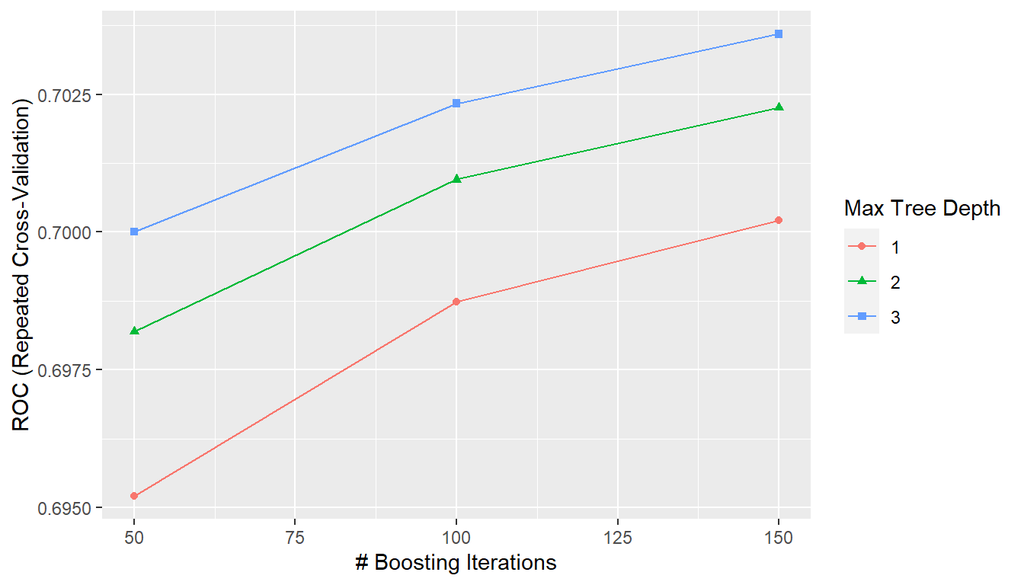

```r
ggplot(model_gbm1)
```

### Inference

#### From the plot, it can observed that the accuracy is improving as the depth and the number of trees increases.

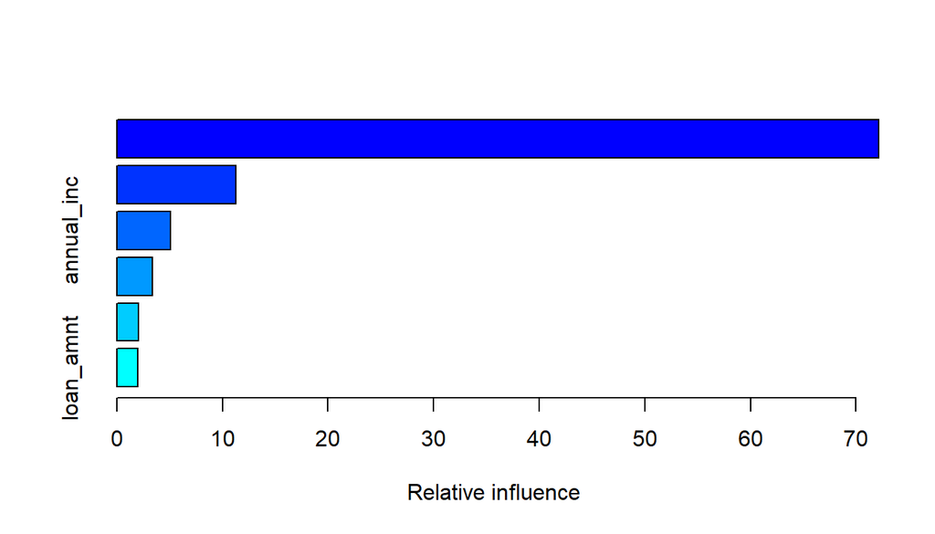

```
##                                     var     rel.inf
## int_rate                       int_rate 72.13432073
## term                               term 11.29565032
## annual_inc                   annual_inc  5.09193474
## fico_range_low           fico_range_low  3.33837736
## installment                 installment  2.02413240
## loan_amnt                     loan_amnt  1.96276324
## gradeC                           gradeC  1.40438331
## inq_last_6mths           inq_last_6mths  0.78149812
## emp_length10+ years emp_length10+ years  0.60206685
## pub_rec                         pub_rec  0.40154877
## gradeB                           gradeB  0.23665396
## delinq_2yrs                 delinq_2yrs  0.19436351
## gradeF                           gradeF  0.13249574
## emp_length6 years     emp_length6 years  0.08355562
## gradeE                           gradeE  0.07246355
## emp_length9 years     emp_length9 years  0.07090228
## emp_length7 years     emp_length7 years  0.06884484
## gradeG                           gradeG  0.03662251
## gradeD                           gradeD  0.02109795
## emp_length3 years     emp_length3 years  0.01930952
## emp_length2 years     emp_length2 years  0.01589451
## emp_length8 years     emp_length8 years  0.01112019
## acc_now_delinq           acc_now_delinq  0.00000000
## emp_length< 1 year   emp_length< 1 year  0.00000000
## emp_length1 year       emp_length1 year  0.00000000
## emp_length4 years     emp_length4 years  0.00000000
## emp_length5 years     emp_length5 years  0.00000000
```

```r
summary(model_gbm1, 6)
```

### Inference

#### ROC curve

```r
pred_gbm <- predict(model_gbm1, test_data, type="prob")
```

```r
roc_gbm <- roc(response = test_data$loan_status, predictor = pred_gbm[,"Charged.Off"])
roc_gbm
```

```
##
## Call:
## roc.default(response = test_data$loan_status, predictor = pred_gbm[,     "Charged.Off"])
##
## Data: pred_gbm[, "Charged.Off"] in 110083 controls (test_data$loan_status Fully.Paid) < 51468 cases (test_data$loan_status Charged.Off).
## Area under the curve: 0.7024
```

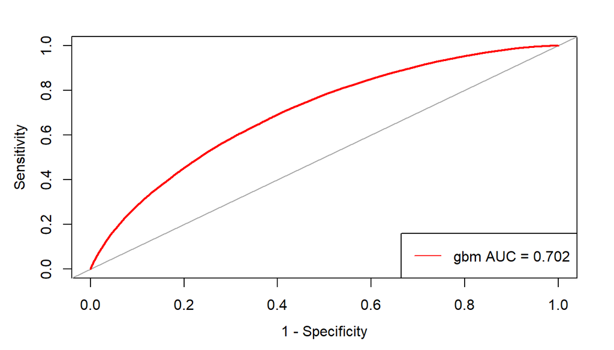

```r
plot.roc(x = roc_gbm, legacy.axes = TRUE, xlim = c(1, 0), asp = NA,
               col = "red", print.auc = FALSE, print.auc.y = .4)

legend(x = "bottomright", legend=c("gbm AUC = 0.702"),
       col = c("red"), lty = 1, cex = 1.0)
```

```r
coords(roc_gbm, "best", ret = "threshold", transpose = TRUE)
```

```
## threshold
## 0.3021864
```

### Inference

#### The threshold should be around 0.30, in order to obtain an even trade-off between sensitivity and specificity.

### Confusion matrix

```r
pred.cls <- ifelse(pred_gbm[,"Charged.Off"] > 0.35, 1, 0)

confusionMatrix(as.factor(pred.cls), test_data$outcome)
```

```
## Confusion Matrix and Statistics
##
##           Reference
## Prediction     0     1
##          0 77164 21436
##          1 32919 30032
##
##                Accuracy : 0.6635
##                  95% CI : (0.6612, 0.6658)
##     No Information Rate : 0.6814
##     P-Value [Acc > NIR] : 1
##
##                   Kappa : 0.2685
##
##  Mcnemar's Test P-Value : <2e-16
##
##             Sensitivity : 0.7010
##             Specificity : 0.5835
##          Pos Pred Value : 0.7826
##          Neg Pred Value : 0.4771
##              Prevalence : 0.6814
##          Detection Rate : 0.4776
##    Detection Prevalence : 0.6103
##       Balanced Accuracy : 0.6422
##
##        'Positive' Class : 0
##
```

### Inference

#### The model achieved an accuracy of 66%.

```r
CM= table( test_data$outcome,pred)
res =err_metric(CM)
```

```
## [1] "Precision value of the model:  0.54"
## [1] "Accuracy of the model:  0.7"
## [1] "Recall value of the model:  0.31"
## [1] "False Positive rate of the model:  0.12"
## [1] "False Negative rate of the model:  0.69"
## [1] "f1 score of the model:  0.39"
```

### Inference

```r
res = round(res, digits = 2)
com_df <- rbind(com_df, c("GBM", res[1], res[2], res[3], res[4]))
kable(com_df)
```

| Algorithm | Accuracy | Precision | Recall | F1.score |
| --- | --- | --- | --- | --- |
| Logistic regression | 0.66 | 0.48 | 0.59 | 0.53 |
| Decision tree | 0.7 | 0.58 | 0.27 | 0.37 |
| Naive bayes | 0.69 | 0.51 | 0.38 | 0.44 |
| Random forest | 0.7 | 0.54 | 0.31 | 0.39 |
| SVM | 0.68 | 0.5 | 0.04 | 0.07 |
| GBM | 0.7 | 0.54 | 0.31 | 0.39 |

### Inference

#### Based on f1-score, logistic regression is the better model.

### XGBoost

```r
tr_data <- sample_n(train_data, 300000)
tr_label <-  tr_data$outcome
tr_data <- tr_data%>%dplyr::select(loan_amnt, term, pub_rec, fico_range_high, grade, int_rate,
                            inq_last_6mths, acc_now_delinq, installment, annual_inc, fico_range_low, delinq_2yrs)


ts_label <-  test_data$outcome
ts_data <- test_data%>%dplyr::select(loan_amnt, term, pub_rec, fico_range_high, grade, int_rate,
                            inq_last_6mths, acc_now_delinq, installment, annual_inc, fico_range_low, delinq_2yrs)


tr_label <- as.numeric(as.character(tr_label))
ts_label <- as.numeric(as.character(ts_label))

xgb.train = xgb.DMatrix(as.matrix(sapply(tr_data, as.numeric)),label=tr_label)
xgb.test = xgb.DMatrix(as.matrix(sapply(ts_data, as.numeric)),label=ts_label)
```

```r
params <- params <- list(booster = "gbtree",
                         objective = "binary:logistic",
                         eta=0.3,
                         gamma=0,
                         min_child_weight=1,
                         subsample=1,
                         colsample_bytree=1)
```

```r
xgb.fit <- xgb.train (params = params,
                      data = xgb.train,
                      nrounds=79,
                      watchlist = list(val=xgb.test,train=xgb.train),
                      early_stopping_rounds=10,
                      nthreads=6,
                      maximize = F,
                      verbose=0,
                      eval_metric = "error")
```

[output not shown]

#### ROC curve

```r
xgbpred <- predict (xgb.fit,xgb.test)


roc_xgb <- roc(response = test_data$outcome, predictor = xgbpred)
roc_xgb
```

```
##
## Call:
## roc.default(response = test_data$outcome, predictor = xgbpred)
##
## Data: xgbpred in 110083 controls (test_data$outcome 0) < 51468 cases (test_data$outcome 1).
## Area under the curve: 0.7052
```

### Inference

#### The threshold should be around 0.32, in order to obtain an even trade-off between sensitivity and specificity.

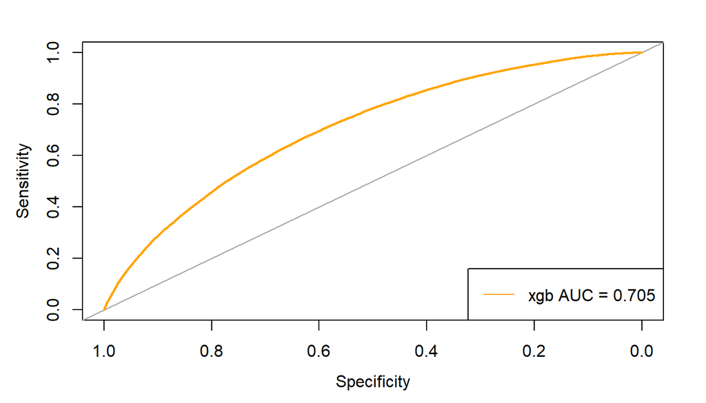

```r
plot.roc(x = roc_xgb, legacy.axes = FALSE, xlim = c(1, 0), asp = NA,
               col = "orange", print.auc = FALSE, print.auc.y = .4)

legend(x = "bottomright", legend=c("xgb AUC = 0.705"),
       col = c("orange"), lty = 1, cex = 1.0)
```

```r
coords(roc_xgb, "best", ret = "threshold", transpose = TRUE)
```

```
## threshold
## 0.3234429
```

#### Confusion Matrix

```r
pred.cls <- factor(ifelse(xgbpred > 0.35 , 1 , 0), levels = c(0,1))
confusionMatrix(pred.cls, as.factor(ts_label))
```

```
## Confusion Matrix and Statistics
##
##           Reference
## Prediction     0     1
##          0 76232 20707
##          1 33851 30761
##
##                Accuracy : 0.6623
##                  95% CI : (0.66, 0.6646)
##     No Information Rate : 0.6814
##     P-Value [Acc > NIR] : 1
##
##                   Kappa : 0.2717
##
##  Mcnemar's Test P-Value : <2e-16
##
##             Sensitivity : 0.6925
##             Specificity : 0.5977
##          Pos Pred Value : 0.7864
##          Neg Pred Value : 0.4761
##              Prevalence : 0.6814
##          Detection Rate : 0.4719
##    Detection Prevalence : 0.6001
##       Balanced Accuracy : 0.6451
##
##        'Positive' Class : 0
##
```

### Inference

```r
CM= table( test_data$outcome,pred)
res =err_metric(CM)
```

```
## [1] "Precision value of the model:  0.54"
## [1] "Accuracy of the model:  0.7"
## [1] "Recall value of the model:  0.31"
## [1] "False Positive rate of the model:  0.12"
## [1] "False Negative rate of the model:  0.69"
## [1] "f1 score of the model:  0.39"
```

### Inference

```r
res = round(res, digits = 2)
com_df <- rbind(com_df, c("XGBoost", res[1], res[2], res[3], res[4]))
kable(com_df)
```

| Algorithm | Accuracy | Precision | Recall | F1.score |
| --- | --- | --- | --- | --- |
| Logistic regression | 0.66 | 0.48 | 0.59 | 0.53 |
| Decision tree | 0.7 | 0.58 | 0.27 | 0.37 |
| Naive bayes | 0.69 | 0.51 | 0.38 | 0.44 |
| Random forest | 0.7 | 0.54 | 0.31 | 0.39 |
| SVM | 0.68 | 0.5 | 0.04 | 0.07 |
| GBM | 0.7 | 0.54 | 0.31 | 0.39 |
| XGBoost | 0.7 | 0.54 | 0.31 | 0.39 |

### Inference

#### Based on f1-score, logistic regression is the better model.

### Comparison

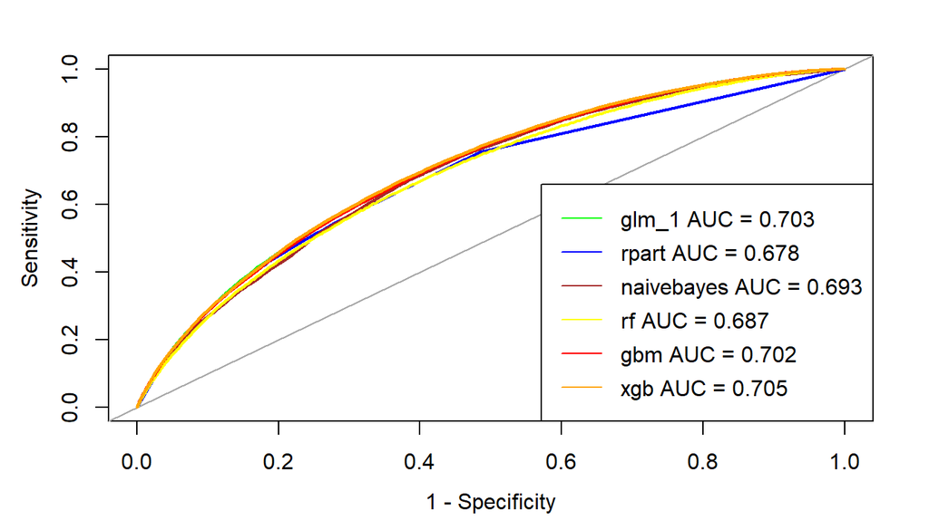

```r
plot.roc(x = roc_glm1, legacy.axes = TRUE, xlim = c(1, 0), asp = NA,
               col = "green")

plot.roc(x = roc_rpart, legacy.axes = TRUE, xlim = c(1, 0), asp = NA,add = TRUE,
               col = "blue")


plot.roc(x = roc_nv, legacy.axes = TRUE, xlim = c(1, 0), asp = NA,add = TRUE,
               col = "brown")

plot.roc(x = roc_rf, legacy.axes = TRUE, xlim = c(1, 0), asp = NA, add = TRUE,
               col = "yellow")

plot.roc(x = roc_gbm, legacy.axes = TRUE, xlim = c(1, 0), asp = NA, add = TRUE,
               col = "red")

plot.roc(x = roc_xgb, legacy.axes = TRUE, xlim = c(1, 0), asp = NA,add = TRUE,
               col = "orange")


legend(x = "bottomright", legend=c("glm_1 AUC = 0.703", "rpart AUC = 0.678","naivebayes AUC = 0.693",
                                   "rf AUC = 0.687", "gbm AUC = 0.702","xgb AUC = 0.705"),
          col = c("green", "blue", "brown", "yellow","red", "orange"), lty = 1, cex = 1.0)
```

### Table

```r
kable(com_df)
```

| Algorithm | Accuracy | Precision | Recall | F1.score |
| --- | --- | --- | --- | --- |
| Logistic regression | 0.66 | 0.48 | 0.59 | 0.53 |
| Decision tree | 0.7 | 0.58 | 0.27 | 0.37 |
| Naive bayes | 0.69 | 0.51 | 0.38 | 0.44 |
| Random forest | 0.7 | 0.54 | 0.31 | 0.39 |
| SVM | 0.68 | 0.5 | 0.04 | 0.07 |
| GBM | 0.7 | 0.54 | 0.31 | 0.39 |
| XGBoost | 0.7 | 0.54 | 0.31 | 0.39 |

## Grade prediction (multiclass classification)

```r
table(loan$grade)
```

```
##
##      A      B      C      D      E      F      G
## 123834 222858 236824 130792  64117  22678   6670
```

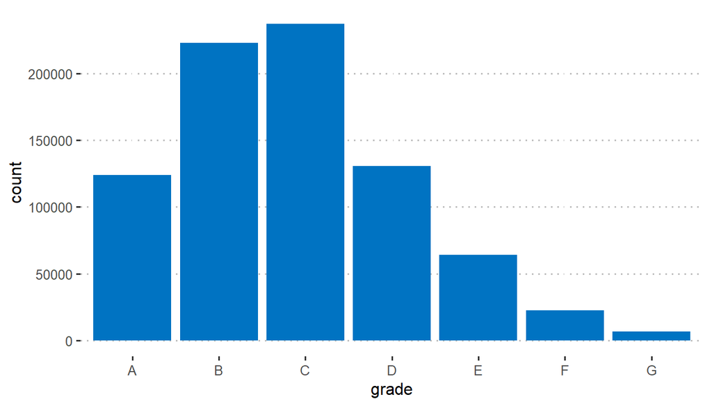

```r
ggplot(loan, aes(x=grade)) + geom_bar(stat='count', fill = "#0073C2FF") + theme_pubclean()
```

### Logistic regression

```r
multi.lr <- multinom(grade ~ loan_amnt + term + pub_rec +fico_range_high+
                        inq_last_6mths+ acc_now_delinq + installment +  annual_inc + fico_range_low + delinq_2yrs,
                        data = train_data)
multi.lr
```

```
## Call:
## multinom(formula = grade ~ loan_amnt + term + pub_rec + fico_range_high +
##     inq_last_6mths + acc_now_delinq + installment + annual_inc +
##     fico_range_low + delinq_2yrs, data = train_data)
##
## Coefficients:
##   (Intercept)    loan_amnt      term     pub_rec fico_range_high inq_last_6mths
## B  -13.877921 -0.001964263 0.8724673  0.04542817      -0.3686913      0.1764057
## C   -4.203443 -0.002837771 1.1849898  0.00118234      -2.8231737      0.4051781
## D   11.608905 -0.003355167 1.3247109 -0.07594465      -6.1921622      0.6091461
## E   -2.516342 -0.003732533 1.4492318 -0.09929763      -3.5060157      0.7279737
## F  -12.537378 -0.004392218 1.6447445 -0.21361449      -1.3675692      0.9943996
## G   -4.770493 -0.004645486 1.7954633 -0.36524362      -4.1802080      1.0945212
##   acc_now_delinq installment    annual_inc fico_range_low  delinq_2yrs
## B      0.8932630  0.06165628 -3.311233e-06      0.3466128  0.005634845
## C      0.8997475  0.08879947 -4.997170e-06      2.7842387 -0.020338875
## D      1.1942174  0.10534306 -8.148900e-06      6.1406369 -0.031066520
## E      1.3065222  0.11769477 -1.104649e-05      3.4497138 -0.054761919
## F      1.5764592  0.13862245 -1.499175e-05      1.2972735 -0.073140681
## G      2.0778968  0.14785805 -1.690287e-05      4.0997795 -0.085204913
##
## Residual Deviance: 1465668
## AIC: 1465800
```

#### Inference

##### This model keeps grade ‘A’ as the baseline and predicts the probability of getting the other grades over ‘A’. The grade with the highest probability is selected.

```r
preds <- predict(multi.lr, test_data, type = "prob")
head(preds)
```

```
##               A          B           C            D            E            F
## 5  1.553322e-08 0.01441676 0.405582713 0.3659974061 1.886859e-01 2.297062e-02
## 7  8.247700e-01 0.15619131 0.017285212 0.0016304109 1.224760e-04 5.580252e-07
## 10 4.912022e-02 0.36057665 0.406921361 0.1611680494 2.164711e-02 5.610345e-04
## 12 9.269437e-01 0.06857810 0.004213672 0.0002496212 1.489715e-05 4.184843e-08
## 13 5.767361e-02 0.35736588 0.399824956 0.1626011713 2.194727e-02 5.820430e-04
## 17 4.214393e-02 0.36246996 0.386379562 0.1777370421 3.034838e-02 9.069114e-04
##               G
## 5  2.346588e-03
## 7  3.334180e-09
## 10 5.580303e-06
## 12 1.333193e-10
## 13 5.065984e-06
## 17 1.421280e-05
```

#### Confusion matrix

```r
pred <- multi.lr %>% predict(test_data)
mean(pred == test_data$grade)
```

```
## [1] 0.5529276
```

```r
confusionMatrix(pred, test_data$grade)
```

```
## Confusion Matrix and Statistics
##
##           Reference
## Prediction     A     B     C     D     E     F     G
##          A 18812  4083   459    21     4     0     1
##          B  5589 29477 12664  2221   299    38     3
##          C   363 10623 27820 13540  3955   464    40
##          D     2   384  6257  8546  4431   844    82
##          E     0     3   156  1642  3023  1559   259
##          F     0     1     8   188  1111  1555   856
##          G     0     0     0     0     0    75    93
##
## Overall Statistics
##
##                Accuracy : 0.5529
##                  95% CI : (0.5505, 0.5554)
##     No Information Rate : 0.2932
##     P-Value [Acc > NIR] : < 2.2e-16
##
##                   Kappa : 0.4151
##
##  Mcnemar's Test P-Value : NA
##
## Statistics by Class:
##
##                      Class: A Class: B Class: C Class: D Class: E Class: F
## Sensitivity            0.7596   0.6613   0.5874   0.3267  0.23575 0.342889
## Specificity            0.9666   0.8221   0.7462   0.9114  0.97567 0.986218
## Pos Pred Value         0.8046   0.5861   0.4897   0.4159  0.45513 0.418123
## Neg Pred Value         0.9569   0.8643   0.8134   0.8751  0.93674 0.981119
## Prevalence             0.1533   0.2759   0.2932   0.1619  0.07937 0.028072
## Detection Rate         0.1164   0.1825   0.1722   0.0529  0.01871 0.009625
## Detection Prevalence   0.1447   0.3113   0.3516   0.1272  0.04111 0.023021
## Balanced Accuracy      0.8631   0.7417   0.6668   0.6190  0.60571 0.664553
##                       Class: G
## Sensitivity          0.0697151
## Specificity          0.9995319
## Pos Pred Value       0.5535714
## Neg Pred Value       0.9923102
## Prevalence           0.0082575
## Detection Rate       0.0005757
## Detection Prevalence 0.0010399
## Balanced Accuracy    0.5346235
```

#### Inference

##### The model achieved an accuracy of 55%.

##### From the sensitivity, it can be observed that the model is good at predicting grades A and B. However, it misses most of the loans with grades E and G.

### Decision tree

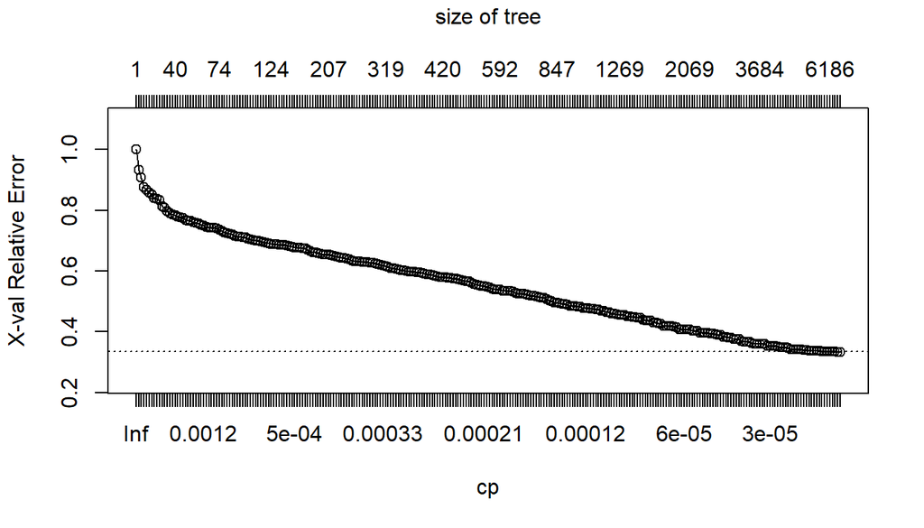

```r
tr_data <- sample_n(train_data, 200000)

ctrl <- rpart.control( cp = 0.00001)
model.tree <- rpart(grade ~ loan_amnt + term + pub_rec +fico_range_high+
                         inq_last_6mths+ acc_now_delinq + installment +  annual_inc + fico_range_low + delinq_2yrs,
                    data=tr_data, method = 'class' , control = ctrl)


plotcp(model.tree)
```

#### Inference

##### From the plot, it can observed that the error decreases as the depth of the tree increases.

#### Importance

```r
imp_dt <- varImp(model.tree)

imp_dt%>%arrange(desc(Overall))
```

```
##                     Overall
## installment     71029.34100
## loan_amnt       54817.77604
## fico_range_high 23394.93380
## fico_range_low  22063.60772
## annual_inc      18111.93334
## term            10724.18006
## inq_last_6mths   8040.39660
## pub_rec          2252.27944
## delinq_2yrs      1928.41356
## acc_now_delinq     16.36668
```

#### Confusion matrix

```r
pred <- predict(model.tree , test_data , type = 'class')

mean(as.factor(pred) == test_data$grade)
```

```
## [1] 0.7669838
```

```r
confusionMatrix(as.factor(pred) , test_data$grade)
```

```
## Confusion Matrix and Statistics
##
##           Reference
## Prediction     A     B     C     D     E     F     G
##          A 20721  3097   518   106    20     4     0
##          B  3724 35334  4536   576   126    24     4
##          C   297  5874 38502  4329   419    94    11
##          D    23   251  3729 18626  3577   278    51
##          E     1    15    72  2473  7585  1221   232
##          F     0     0     7    48   965  2529   426
##          G     0     0     0     0   131   385   610
##
## Overall Statistics
##
##                Accuracy : 0.767
##                  95% CI : (0.7649, 0.769)
##     No Information Rate : 0.2932
##     P-Value [Acc > NIR] : < 2.2e-16
##
##                   Kappa : 0.7006
##
##  Mcnemar's Test P-Value : NA
##
## Statistics by Class:
##
##                      Class: A Class: B Class: C Class: D Class: E Class: F
## Sensitivity            0.8367   0.7928   0.8129   0.7121  0.59152  0.55766
## Specificity            0.9726   0.9231   0.9035   0.9416  0.97301  0.99079
## Pos Pred Value         0.8469   0.7972   0.7774   0.7019  0.65394  0.63623
## Neg Pred Value         0.9705   0.9212   0.9209   0.9442  0.96507  0.98727
## Prevalence             0.1533   0.2759   0.2932   0.1619  0.07937  0.02807
## Detection Rate         0.1283   0.2187   0.2383   0.1153  0.04695  0.01565
## Detection Prevalence   0.1514   0.2744   0.3066   0.1643  0.07180  0.02461
## Balanced Accuracy      0.9046   0.8580   0.8582   0.8268  0.78226  0.77423
##                      Class: G
## Sensitivity          0.457271
## Specificity          0.996779
## Pos Pred Value       0.541741
## Neg Pred Value       0.995487
## Prevalence           0.008257
## Detection Rate       0.003776
## Detection Prevalence 0.006970
## Balanced Accuracy    0.727025
```

#### Inference

##### The model achieved an accuracy of 76%.

##### From the sensitivity, it can be observed that the model is good at predicting grades A, B, C and D. It even performs fairly well in predicting grades E, F and G.

### Naive bayes

```r
nv.grade <- naiveBayes(grade ~ application_type+emp_length+issue_mon+issue_yr+term+loan_status,data=train_data)
```

#### Confusion matrix

```r
pred.cls <- nv.grade%>%predict(test_data)
confusionMatrix(pred.cls , test_data$grade)
```

```
## Confusion Matrix and Statistics
##
##           Reference
## Prediction     A     B     C     D     E     F     G
##          A 19948 27212 20711  8322  2193   426    67
##          B  2173  5653  4400  2657   667   116    13
##          C  2579 10682 18717 11558  6653  2587   824
##          D    30   417  1736  1729  1421   641   203
##          E    36   607  1800  1892  1889   765   227
##          F     0     0     0     0     0     0     0
##          G     0     0     0     0     0     0     0
##
## Overall Statistics
##
##                Accuracy : 0.2967
##                  95% CI : (0.2945, 0.299)
##     No Information Rate : 0.2932
##     P-Value [Acc > NIR] : 0.0009036
##
##                   Kappa : 0.1113
##
##  Mcnemar's Test P-Value : NA
##
## Statistics by Class:
##
##                      Class: A Class: B Class: C Class: D Class: E Class: F
## Sensitivity            0.8055  0.12683   0.3952  0.06610  0.14731  0.00000
## Specificity            0.5692  0.91429   0.6945  0.96715  0.96418  1.00000
## Pos Pred Value         0.2529  0.36055   0.3492  0.27991  0.26178      NaN
## Neg Pred Value         0.9417  0.73320   0.7346  0.84277  0.92915  0.97193
## Prevalence             0.1533  0.27589   0.2932  0.16192  0.07937  0.02807
## Detection Rate         0.1235  0.03499   0.1159  0.01070  0.01169  0.00000
## Detection Prevalence   0.4883  0.09705   0.3318  0.03824  0.04467  0.00000
## Balanced Accuracy      0.6873  0.52056   0.5448  0.51662  0.55575  0.50000
##                      Class: G
## Sensitivity          0.000000
## Specificity          1.000000
## Pos Pred Value            NaN
## Neg Pred Value       0.991743
## Prevalence           0.008257
## Detection Rate       0.000000
## Detection Prevalence 0.000000
## Balanced Accuracy    0.500000
```

#### Inference

##### The model achieved an accuracy of 29%

##### From the sensitivity, it can be observed that the model is only good at predicting grade A. It does not predict any of the other grades accurately.

### Random forest

```r
tr_data <- sample_n(train_data, 200000)
model <- randomForest(grade ~ loan_amnt + term + pub_rec +fico_range_high+
                         inq_last_6mths+ acc_now_delinq + installment +  annual_inc + fico_range_low + delinq_2yrs  ,
                         data = tr_data,method="rf", trcontrol= trainControl("cv",number = 10),importance=TRUE)
```

##### Importance

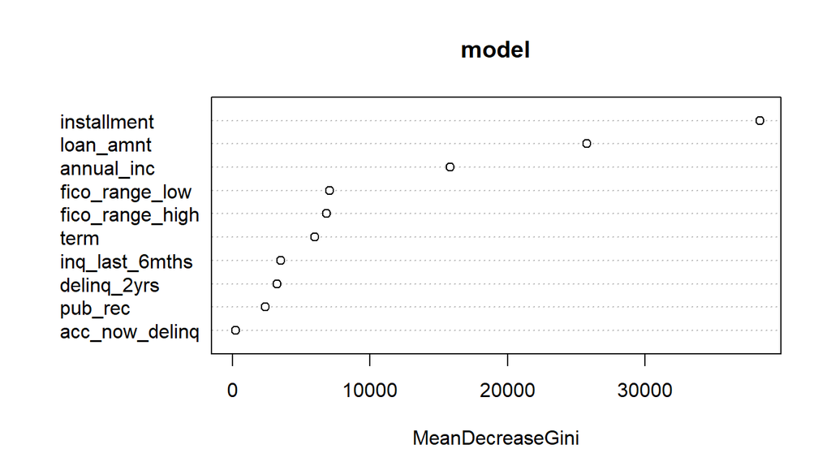

```r
varImpPlot(model,type=2)
```

#### Inference

##### It can be observed that installment,loan amount, annual income, fico score and term are the top most important features used by the random forest to predict grade.

#### Confusion matrix

```r
pred <- model %>% predict(test_data)
mean(pred == test_data$grade)
```

```
## [1] 0.6495163
```

```r
confusionMatrix(pred, test_data$grade)
```

```
## Confusion Matrix and Statistics
##
##           Reference
## Prediction     A     B     C     D     E     F     G
##          A 17499  4115  1300   363    59    12     0
##          B  6700 32482  8817  2534   571    97    10
##          C   555  7880 35190  9165  2011   429    74
##          D    10    93  2018 12607  4252   453    80
##          E     2     1    35  1478  5342  1796   344
##          F     0     0     3    11   566  1618   634
##          G     0     0     1     0    22   130   192
##
## Overall Statistics
##
##                Accuracy : 0.6495
##                  95% CI : (0.6472, 0.6518)
##     No Information Rate : 0.2932
##     P-Value [Acc > NIR] : < 2.2e-16
##
##                   Kappa : 0.5422
##
##  Mcnemar's Test P-Value : NA
##
## Statistics by Class:
##
##                      Class: A Class: B Class: C Class: D Class: E Class: F
## Sensitivity            0.7066   0.7288   0.7430  0.48196  0.41660  0.35678
## Specificity            0.9572   0.8399   0.8239  0.94899  0.97542  0.99227
## Pos Pred Value         0.7495   0.6343   0.6363  0.64608  0.59369  0.57133
## Neg Pred Value         0.9474   0.8904   0.8854  0.90460  0.95096  0.98162
## Prevalence             0.1533   0.2759   0.2932  0.16192  0.07937  0.02807
## Detection Rate         0.1083   0.2011   0.2178  0.07804  0.03307  0.01002
## Detection Prevalence   0.1445   0.3170   0.3423  0.12079  0.05570  0.01753
## Balanced Accuracy      0.8319   0.7843   0.7834  0.71547  0.69601  0.67452
##                      Class: G
## Sensitivity          0.143928
## Specificity          0.999045
## Pos Pred Value       0.556522
## Neg Pred Value       0.992916
## Prevalence           0.008257
## Detection Rate       0.001188
## Detection Prevalence 0.002136
## Balanced Accuracy    0.571487
```

#### Inference

##### The model achieved an accuracy of 64%.

##### From the sensitivity, it can be observed that the model is fairly good at predicting grades A, B and C. It does not predict grades F and G properly.

### XGBoost

```r
tr_data <- sample_n(train_data, 200000)

tr_label <-  unclass(tr_data$grade)
tr_label <- tr_label - 1

tr_data <- tr_data%>%dplyr::select(loan_amnt, term,fico_range_high,
                            inq_last_6mths, acc_now_delinq, installment, annual_inc, fico_range_low, delinq_2yrs)


ts_label <-  unclass(test_data$grade)
ts_label <- ts_label - 1
ts_data <- test_data%>%dplyr::select(loan_amnt, term,  fico_range_high,
                            inq_last_6mths, acc_now_delinq, installment, annual_inc, fico_range_low, delinq_2yrs)


xgb.train = xgb.DMatrix(as.matrix(sapply(tr_data, as.numeric)),label=tr_label)
xgb.test = xgb.DMatrix(as.matrix(sapply(ts_data, as.numeric)),label=ts_label)
```

```r
num_class = 7
params = list(
  booster="gbtree",
  eta=0.001,
  max_depth=5,
  gamma=3,
  subsample=0.75,
  colsample_bytree=1,
  objective="multi:softprob",
  eval_metric="mlogloss",
  num_class=num_class
)
```

```r
xgb.fit=xgb.train(
  params=params,
  data=xgb.train,
  nrounds=79,
  nthreads=4,
  early_stopping_rounds=10,
  watchlist=list(val1=xgb.train,val2=xgb.test),
  verbose=0
)
```

[output not shown]

```r
xgb.pred = predict(xgb.fit,xgb.test,reshape=T)

xgb.pred = as.data.frame(xgb.pred)

colnames(xgb.pred) = levels(test_data$grade)
```

#### Confusion matrix

```r
pred.cls = apply(xgb.pred,1,function(x) colnames(xgb.pred)[which.max(x)])

pred.cls <- factor(pred.cls, levels = c("A", "B", "C", "D", "E", "F", "G"))

confusionMatrix(pred.cls, test_data$grade)
```

```
## Confusion Matrix and Statistics
##
##           Reference
## Prediction     A     B     C     D     E     F     G
##          A 12779  5528  2445   798   166    31     3
##          B 10825 29660 19401  8720  2325   464    85
##          C  1119  8917 24271 13305  6987  2288   606
##          D    43   466  1246  2976  1748   495   142
##          E     0     0     1   346  1131   378    89
##          F     0     0     0    13   393   722   198
##          G     0     0     0     0    73   157   211
##
## Overall Statistics
##
##                Accuracy : 0.4441
##                  95% CI : (0.4417, 0.4466)
##     No Information Rate : 0.2932
##     P-Value [Acc > NIR] : < 2.2e-16
##
##                   Kappa : 0.2535
##
##  Mcnemar's Test P-Value : < 2.2e-16
##
## Statistics by Class:
##
##                      Class: A Class: B Class: C Class: D Class: E Class: F
## Sensitivity            0.5160   0.6655   0.5124  0.11377 0.088201 0.159206
## Specificity            0.9344   0.6425   0.7091  0.96942 0.994527 0.996153
## Pos Pred Value         0.5875   0.4149   0.4222  0.41821 0.581491 0.544495
## Neg Pred Value         0.9143   0.8345   0.7781  0.84989 0.926745 0.976202
## Prevalence             0.1533   0.2759   0.2932  0.16192 0.079374 0.028072
## Detection Rate         0.0791   0.1836   0.1502  0.01842 0.007001 0.004469
## Detection Prevalence   0.1346   0.4425   0.3559  0.04405 0.012040 0.008208
## Balanced Accuracy      0.7252   0.6540   0.6107  0.54160 0.541364 0.577680
##                      Class: G
## Sensitivity          0.158171
## Specificity          0.998564
## Pos Pred Value       0.478458
## Neg Pred Value       0.993030
## Prevalence           0.008257
## Detection Rate       0.001306
## Detection Prevalence 0.002730
## Balanced Accuracy    0.578368
```

#### Inference

##### The model achieved an accuracy of 44%.

##### From the sensitivity, it can be observed that the model does not predict the grades accurately.

### Comparison

#### Logistic regression - 55.29%

#### Decision tree - 76.7%

#### Naive bayes - 29%

#### Random forest - 64.95%

#### XGBoost - 44.41%

#### Conclusion: Decision tree was found to have the highest accuracy in predicting grade.